# Wine Investigation by Minkun Kim

## show margin: Tools > global options > code > display

## Gather the dataset

[output not shown]

[output not shown]

[output not shown]

[output not shown]

```
##   X fixed.acidity volatile.acidity citric.acid residual.sugar chlorides
## 1 1           7.4             0.70        0.00            1.9     0.076
## 2 2           7.8             0.88        0.00            2.6     0.098
## 3 3           7.8             0.76        0.04            2.3     0.092
##   free.sulfur.dioxide total.sulfur.dioxide density   pH sulphates alcohol
## 1                  11                   34  0.9978 3.51      0.56     9.4
## 2                  25                   67  0.9968 3.20      0.68     9.8
## 3                  15                   54  0.9970 3.26      0.65     9.8
##   quality
## 1       5
## 2       5
## 3       5
```

```
## 'data.frame':    1599 obs. of  13 variables:
##  $ X                   : int  1 2 3 4 5 6 7 8 9 10 ...
##  $ fixed.acidity       : num  7.4 7.8 7.8 11.2 7.4 7.4 7.9 7.3 7.8 7.5 ...
##  $ volatile.acidity    : num  0.7 0.88 0.76 0.28 0.7 0.66 0.6 0.65 0.58 0.5 ...
##  $ citric.acid         : num  0 0 0.04 0.56 0 0 0.06 0 0.02 0.36 ...
##  $ residual.sugar      : num  1.9 2.6 2.3 1.9 1.9 1.8 1.6 1.2 2 6.1 ...
##  $ chlorides           : num  0.076 0.098 0.092 0.075 0.076 0.075 0.069 0.065 0.073 0.071 ...
##  $ free.sulfur.dioxide : num  11 25 15 17 11 13 15 15 9 17 ...
##  $ total.sulfur.dioxide: num  34 67 54 60 34 40 59 21 18 102 ...
##  $ density             : num  0.998 0.997 0.997 0.998 0.998 ...
##  $ pH                  : num  3.51 3.2 3.26 3.16 3.51 3.51 3.3 3.39 3.36 3.35 ...
##  $ sulphates           : num  0.56 0.68 0.65 0.58 0.56 0.56 0.46 0.47 0.57 0.8 ...
##  $ alcohol             : num  9.4 9.8 9.8 9.8 9.4 9.4 9.4 10 9.5 10.5 ...
##  $ quality             : int  5 5 5 6 5 5 5 7 7 5 ...
```

```
##        X          fixed.acidity   volatile.acidity  citric.acid
##  Min.   :   1.0   Min.   : 4.60   Min.   :0.1200   Min.   :0.000
##  1st Qu.: 400.5   1st Qu.: 7.10   1st Qu.:0.3900   1st Qu.:0.090
##  Median : 800.0   Median : 7.90   Median :0.5200   Median :0.260
##  Mean   : 800.0   Mean   : 8.32   Mean   :0.5278   Mean   :0.271
##  3rd Qu.:1199.5   3rd Qu.: 9.20   3rd Qu.:0.6400   3rd Qu.:0.420
##  Max.   :1599.0   Max.   :15.90   Max.   :1.5800   Max.   :1.000
##  residual.sugar     chlorides       free.sulfur.dioxide
##  Min.   : 0.900   Min.   :0.01200   Min.   : 1.00
##  1st Qu.: 1.900   1st Qu.:0.07000   1st Qu.: 7.00
##  Median : 2.200   Median :0.07900   Median :14.00
##  Mean   : 2.539   Mean   :0.08747   Mean   :15.87
##  3rd Qu.: 2.600   3rd Qu.:0.09000   3rd Qu.:21.00
##  Max.   :15.500   Max.   :0.61100   Max.   :72.00
##  total.sulfur.dioxide    density             pH          sulphates
##  Min.   :  6.00       Min.   :0.9901   Min.   :2.740   Min.   :0.3300
##  1st Qu.: 22.00       1st Qu.:0.9956   1st Qu.:3.210   1st Qu.:0.5500
##  Median : 38.00       Median :0.9968   Median :3.310   Median :0.6200
##  Mean   : 46.47       Mean   :0.9967   Mean   :3.311   Mean   :0.6581
##  3rd Qu.: 62.00       3rd Qu.:0.9978   3rd Qu.:3.400   3rd Qu.:0.7300
##  Max.   :289.00       Max.   :1.0037   Max.   :4.010   Max.   :2.0000
##     alcohol         quality
##  Min.   : 8.40   Min.   :3.000
##  1st Qu.: 9.50   1st Qu.:5.000
##  Median :10.20   Median :6.000
##  Mean   :10.42   Mean   :5.636
##  3rd Qu.:11.10   3rd Qu.:6.000
##  Max.   :14.90   Max.   :8.000
```

```
##   X fixed.acidity volatile.acidity citric.acid residual.sugar chlorides
## 1 1           7.0             0.27        0.36           20.7     0.045
## 2 2           6.3             0.30        0.34            1.6     0.049
## 3 3           8.1             0.28        0.40            6.9     0.050
##   free.sulfur.dioxide total.sulfur.dioxide density   pH sulphates alcohol
## 1                  45                  170  1.0010 3.00      0.45     8.8
## 2                  14                  132  0.9940 3.30      0.49     9.5
## 3                  30                   97  0.9951 3.26      0.44    10.1
##   quality
## 1       6
## 2       6
## 3       6
```

```
## 'data.frame':    4898 obs. of  13 variables:
##  $ X                   : int  1 2 3 4 5 6 7 8 9 10 ...
##  $ fixed.acidity       : num  7 6.3 8.1 7.2 7.2 8.1 6.2 7 6.3 8.1 ...
##  $ volatile.acidity    : num  0.27 0.3 0.28 0.23 0.23 0.28 0.32 0.27 0.3 0.22 ...
##  $ citric.acid         : num  0.36 0.34 0.4 0.32 0.32 0.4 0.16 0.36 0.34 0.43 ...
##  $ residual.sugar      : num  20.7 1.6 6.9 8.5 8.5 6.9 7 20.7 1.6 1.5 ...
##  $ chlorides           : num  0.045 0.049 0.05 0.058 0.058 0.05 0.045 0.045 0.049 0.044 ...
##  $ free.sulfur.dioxide : num  45 14 30 47 47 30 30 45 14 28 ...
##  $ total.sulfur.dioxide: num  170 132 97 186 186 97 136 170 132 129 ...
##  $ density             : num  1.001 0.994 0.995 0.996 0.996 ...
##  $ pH                  : num  3 3.3 3.26 3.19 3.19 3.26 3.18 3 3.3 3.22 ...
##  $ sulphates           : num  0.45 0.49 0.44 0.4 0.4 0.44 0.47 0.45 0.49 0.45 ...
##  $ alcohol             : num  8.8 9.5 10.1 9.9 9.9 10.1 9.6 8.8 9.5 11 ...
##  $ quality             : int  6 6 6 6 6 6 6 6 6 6 ...
```

```
##        X        fixed.acidity    volatile.acidity  citric.acid
##  Min.   :   1   Min.   : 3.800   Min.   :0.0800   Min.   :0.0000
##  1st Qu.:1225   1st Qu.: 6.300   1st Qu.:0.2100   1st Qu.:0.2700
##  Median :2450   Median : 6.800   Median :0.2600   Median :0.3200
##  Mean   :2450   Mean   : 6.855   Mean   :0.2782   Mean   :0.3342
##  3rd Qu.:3674   3rd Qu.: 7.300   3rd Qu.:0.3200   3rd Qu.:0.3900
##  Max.   :4898   Max.   :14.200   Max.   :1.1000   Max.   :1.6600
##  residual.sugar     chlorides       free.sulfur.dioxide
##  Min.   : 0.600   Min.   :0.00900   Min.   :  2.00
##  1st Qu.: 1.700   1st Qu.:0.03600   1st Qu.: 23.00
##  Median : 5.200   Median :0.04300   Median : 34.00
##  Mean   : 6.391   Mean   :0.04577   Mean   : 35.31
##  3rd Qu.: 9.900   3rd Qu.:0.05000   3rd Qu.: 46.00
##  Max.   :65.800   Max.   :0.34600   Max.   :289.00
##  total.sulfur.dioxide    density             pH          sulphates
##  Min.   :  9.0        Min.   :0.9871   Min.   :2.720   Min.   :0.2200
##  1st Qu.:108.0        1st Qu.:0.9917   1st Qu.:3.090   1st Qu.:0.4100
##  Median :134.0        Median :0.9937   Median :3.180   Median :0.4700
##  Mean   :138.4        Mean   :0.9940   Mean   :3.188   Mean   :0.4898
##  3rd Qu.:167.0        3rd Qu.:0.9961   3rd Qu.:3.280   3rd Qu.:0.5500
##  Max.   :440.0        Max.   :1.0390   Max.   :3.820   Max.   :1.0800
##     alcohol         quality
##  Min.   : 8.00   Min.   :3.000
##  1st Qu.: 9.50   1st Qu.:5.000
##  Median :10.40   Median :6.000
##  Mean   :10.51   Mean   :5.878
##  3rd Qu.:11.40   3rd Qu.:6.000
##  Max.   :14.20   Max.   :9.000
```

### Wine Quality Dataset

> Created by: Paulo Cortez (Univ. Minho), Antonio Cerdeira, Fernando Almeida, Telmo Matos and Jose Reis (CVRVV) @ 2009 Available at: [@Elsevier] http://dx.doi.org/10.1016/j.dss.2009.05.016 [Pre-press (pdf)] http://www3.dsi.uminho.pt/pcortez/winequality09.pdf [bib] http://www3.dsi.uminho.pt/pcortez/dss09.bib

> The two datasets are related to red and white variants of the Portuguese “Vinho Verde” wine. The ‘wineQualityReds’ contains 1,599 red wines with 11 variables and the ‘wineQualityWhites’ contains 4,898 white wines with 11 variables on the chemical properties of the wine. At least 3 wine experts rated the quality of each wine, providing a rating between 0 (very bad) and 10 (very excellent).

#### Description of attributes:

> 1 - fixed acidity: (tartaric acid - g / dm^3) most acids involved with wine or fixed or nonvolatile (do not evaporate readily)

> 2 - volatile acidity: (acetic acid - g / dm^3) the amount of acetic acid in wine, which at too high of levels can lead to an unpleasant, vinegar taste

> 3 - citric acid: (g / dm^3) found in small quantities, citric acid can add ‘freshness’ and flavor to wines

> 4 - residual sugar: (g / dm^3) the amount of sugar remaining after fermentation stops, it’s rare to find wines with less than 1 gram/liter and wines with greater than 45 grams/liter are considered sweet

> 5 - chlorides: (sodium chloride - g / dm^3) the amount of salt in the wine

> 6 - free sulfur dioxide: (mg / dm^3) the free form of SO2 exists in equilibrium between molecular SO2 (as a dissolved gas) and bisulfite ion; it prevents microbial growth and the oxidation of wine

> 7 - total sulfur dioxide: (mg / dm^3) amount of free and bound forms of S02; in low concentrations, SO2 is mostly undetectable in wine, but at free SO2 concentrations over 50 ppm, SO2 becomes evident in the nose and taste of wine

> 8 - density: (g / cm^3) the density of water is close to that of water depending on the percent alcohol and sugar content

> 9 - pH: describes how acidic or basic a wine is on a scale from 0 (very acidic) to 14 (very basic); most wines are between 3-4 on the pH scale

> 10 - sulphates: (potassium sulphate - g / dm^3)) a wine additive which can contribute to sulfur dioxide gas (S02) levels, which acts as an antimicrobial and antioxidant

> 11 - alcohol: (% by volume) the percent alcohol content of the wine

> 12 - quality: (score between 0 and 10) Output variable based on sensory data

## Combine the two.

```
## 'data.frame':    6497 obs. of  15 variables:
##  $ fixed.acidity       : num  7 7.4 6.3 7.8 7.8 8.1 7.2 11.2 7.2 7.4 ...
##  $ volatile.acidity    : num  0.27 0.7 0.3 0.88 0.76 0.28 0.23 0.28 0.23 0.7 ...
##  $ citric.acid         : num  0.36 0 0.34 0 0.04 0.4 0.32 0.56 0.32 0 ...
##  $ residual.sugar      : num  20.7 1.9 1.6 2.6 2.3 6.9 8.5 1.9 8.5 1.9 ...
##  $ chlorides           : num  0.045 0.076 0.049 0.098 0.092 0.05 0.058 0.075 0.058 0.076 ...
##  $ free.sulfur.dioxide : num  45 11 14 25 15 30 47 17 47 11 ...
##  $ total.sulfur.dioxide: num  170 34 132 67 54 97 186 60 186 34 ...
##  $ density             : num  1.001 0.998 0.994 0.997 0.997 ...
##  $ pH                  : num  3 3.51 3.3 3.2 3.26 3.26 3.19 3.16 3.19 3.51 ...
##  $ sulphates           : num  0.45 0.56 0.49 0.68 0.65 0.44 0.4 0.58 0.4 0.56 ...
##  $ alcohol             : num  8.8 9.4 9.5 9.8 9.8 10.1 9.9 9.8 9.9 9.4 ...
##  $ quality             : Factor w/ 7 levels "3","4","5","6",..: 4 3 4 3 3 4 4 4 4 3 ...
##  $ color_red           : Factor w/ 2 levels "0","1": 1 2 1 2 2 1 1 2 1 2 ...
##  $ color_white         : Factor w/ 2 levels "0","1": 2 1 2 1 1 2 2 1 2 1 ...
##  $ colors              : Factor w/ 2 levels "red","white": 2 1 2 1 1 2 2 1 2 1 ...
```

```
##    fixed.acidity volatile.acidity citric.acid residual.sugar chlorides
## 1            7.0             0.27        0.36           20.7     0.045
## 2            7.4             0.70        0.00            1.9     0.076
## 3            6.3             0.30        0.34            1.6     0.049
## 4            7.8             0.88        0.00            2.6     0.098
## 5            7.8             0.76        0.04            2.3     0.092
## 6            8.1             0.28        0.40            6.9     0.050
## 7            7.2             0.23        0.32            8.5     0.058
## 8           11.2             0.28        0.56            1.9     0.075
## 9            7.2             0.23        0.32            8.5     0.058
## 10           7.4             0.70        0.00            1.9     0.076
##    free.sulfur.dioxide total.sulfur.dioxide density   pH sulphates alcohol
## 1                   45                  170  1.0010 3.00      0.45     8.8
## 2                   11                   34  0.9978 3.51      0.56     9.4
## 3                   14                  132  0.9940 3.30      0.49     9.5
```

[output cut: 18 more lines]

#### Our combined wineQuality dataset consists of 12 variables, with 6497 observations(red:1599/white:4898)

# [Univariate Plots Section]

## Plot every predictor.

## fixed.acidity

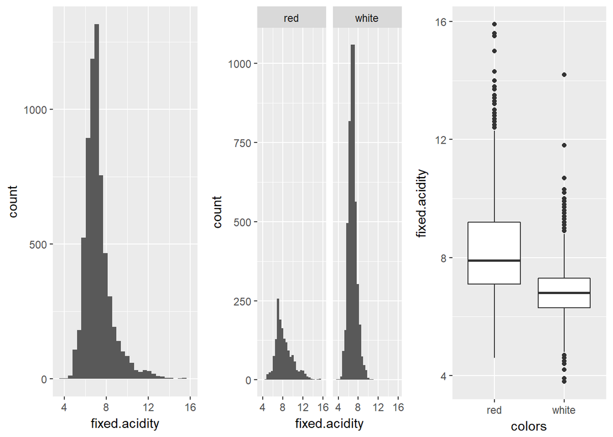

```
## df_wine$colors: red
##    Min. 1st Qu.  Median    Mean 3rd Qu.    Max.
##    4.60    7.10    7.90    8.32    9.20   15.90
## --------------------------------------------------------
## df_wine$colors: white
##    Min. 1st Qu.  Median    Mean 3rd Qu.    Max.
##   3.800   6.300   6.800   6.855   7.300  14.200
```

### So many outliers. Let’s limit the range(3, 10) for ‘fixed.acidity’

## volatile.acidity

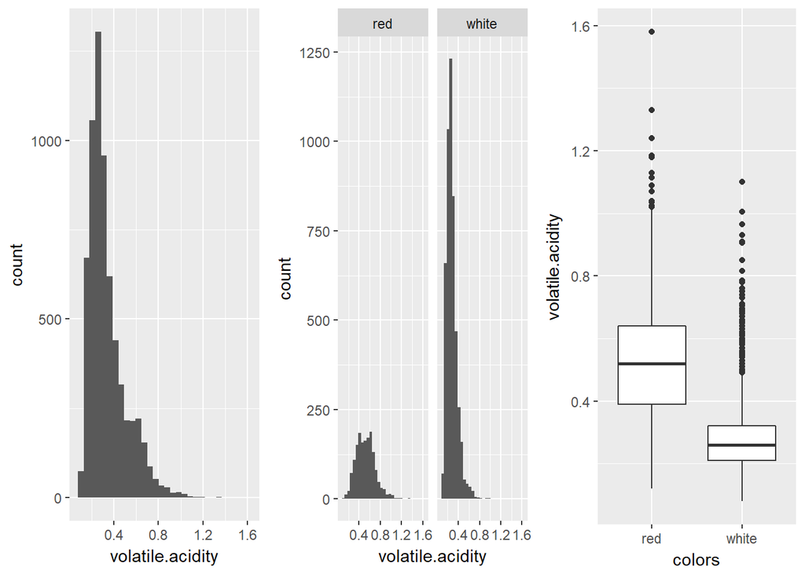

```
## df_wine$colors: red
##    Min. 1st Qu.  Median    Mean 3rd Qu.    Max.
##  0.1200  0.3900  0.5200  0.5278  0.6400  1.5800
## --------------------------------------------------------
## df_wine$colors: white
##    Min. 1st Qu.  Median    Mean 3rd Qu.    Max.
##  0.0800  0.2100  0.2600  0.2782  0.3200  1.1000
```

### So many outliers. Let’s limit the range(0, 0.7) for ‘volatile.acidity’

## citric.acid

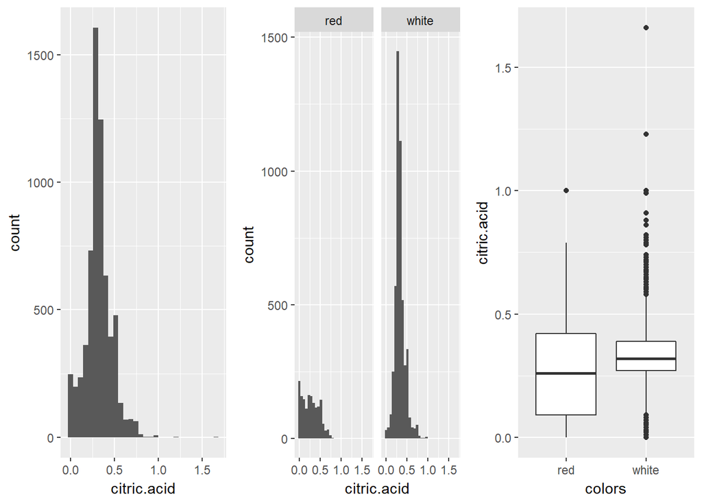

```
## df_wine$colors: red
##    Min. 1st Qu.  Median    Mean 3rd Qu.    Max.
##   0.000   0.090   0.260   0.271   0.420   1.000
## --------------------------------------------------------
## df_wine$colors: white
##    Min. 1st Qu.  Median    Mean 3rd Qu.    Max.
##  0.0000  0.2700  0.3200  0.3342  0.3900  1.6600
```

### So many outliers. Let’s limit the range(0, 0.5) for ‘citric.acid’

## chlorides

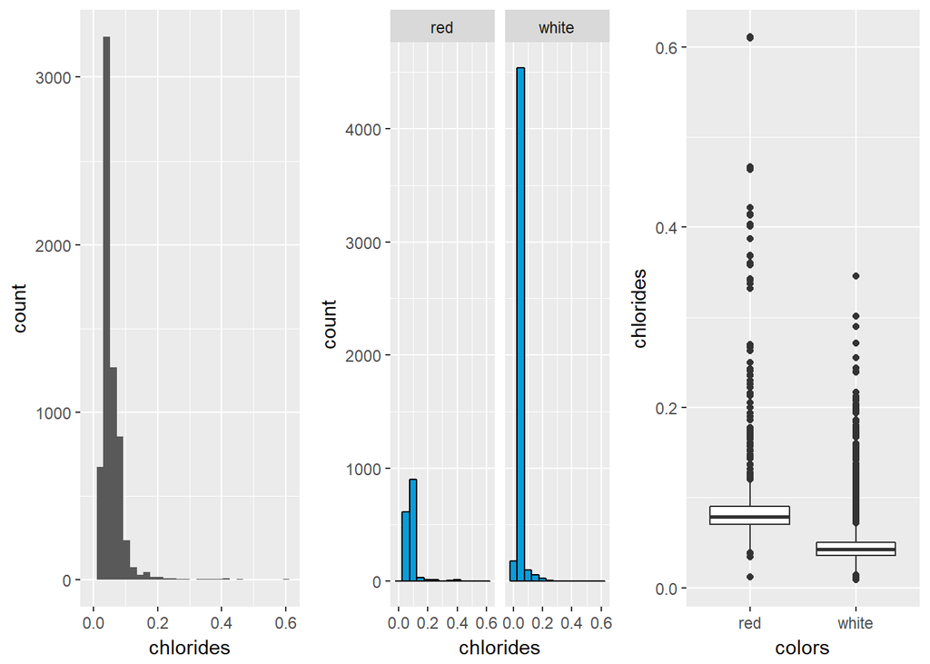

```
## df_wine$colors: red
##    Min. 1st Qu.  Median    Mean 3rd Qu.    Max.
## 0.01200 0.07000 0.07900 0.08747 0.09000 0.61100
## --------------------------------------------------------
## df_wine$colors: white
##    Min. 1st Qu.  Median    Mean 3rd Qu.    Max.
## 0.00900 0.03600 0.04300 0.04577 0.05000 0.34600
```

### So many outliers. Let’s limit the range(0, 0.1) for ‘chlorides’

## free.sulfur.dioxide

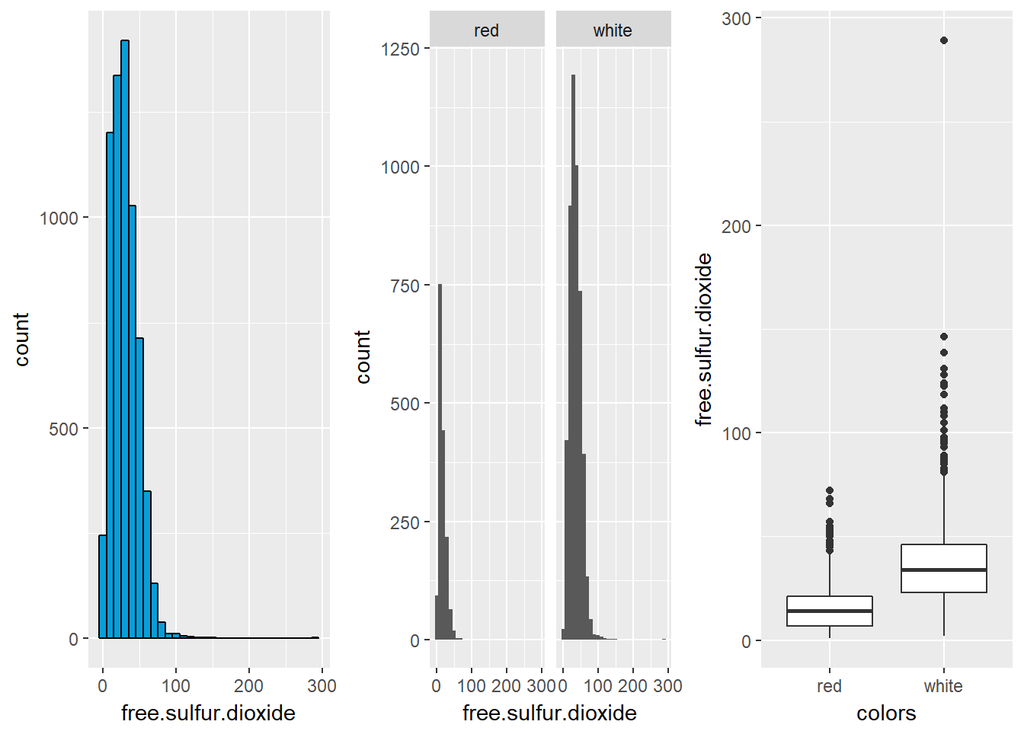

```
## df_wine$colors: red
##    Min. 1st Qu.  Median    Mean 3rd Qu.    Max.
##    1.00    7.00   14.00   15.87   21.00   72.00
## --------------------------------------------------------
## df_wine$colors: white
##    Min. 1st Qu.  Median    Mean 3rd Qu.    Max.
##    2.00   23.00   34.00   35.31   46.00  289.00
```

### So many outliers. Let’s limit the range(0, 50) for ‘free.sulfur.dioxide’

## density

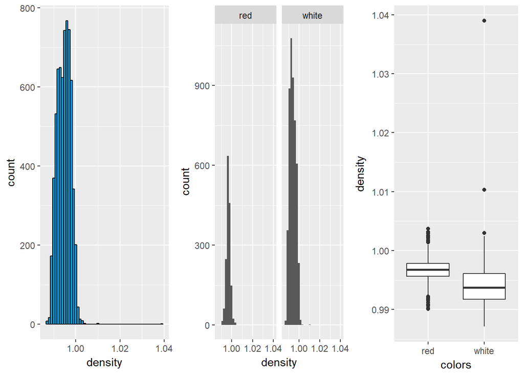

```
## df_wine$colors: red
##    Min. 1st Qu.  Median    Mean 3rd Qu.    Max.
##  0.9901  0.9956  0.9968  0.9967  0.9978  1.0040
## --------------------------------------------------------
## df_wine$colors: white
##    Min. 1st Qu.  Median    Mean 3rd Qu.    Max.
##  0.9871  0.9917  0.9937  0.9940  0.9961  1.0390
```

### So many outliers. Let’s limit the range(0.9, 1) for ‘density’

## sulphates

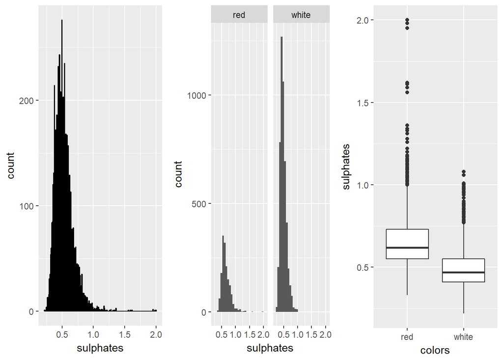

```
## df_wine$colors: red
##    Min. 1st Qu.  Median    Mean 3rd Qu.    Max.
##  0.3300  0.5500  0.6200  0.6581  0.7300  2.0000
## --------------------------------------------------------
## df_wine$colors: white
##    Min. 1st Qu.  Median    Mean 3rd Qu.    Max.
##  0.2200  0.4100  0.4700  0.4898  0.5500  1.0800
```

### So many outliers. Let’s limit the range(0, 0.8) for ‘sulphates’

## residual.sugar

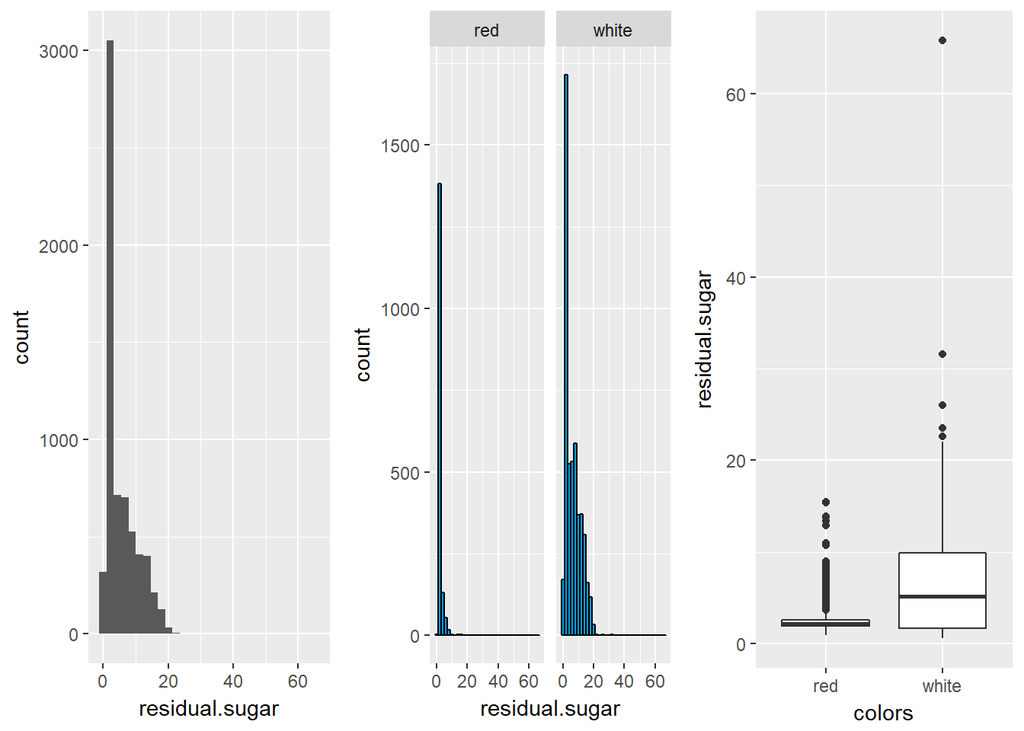

```
## df_wine$colors: red
##    Min. 1st Qu.  Median    Mean 3rd Qu.    Max.
##   0.900   1.900   2.200   2.539   2.600  15.500
## --------------------------------------------------------
## df_wine$colors: white
##    Min. 1st Qu.  Median    Mean 3rd Qu.    Max.
##   0.600   1.700   5.200   6.391   9.900  65.800
```

### So many outliers. Let’s limit the range(0.5, 10) for ‘residual.sugar’

## pH

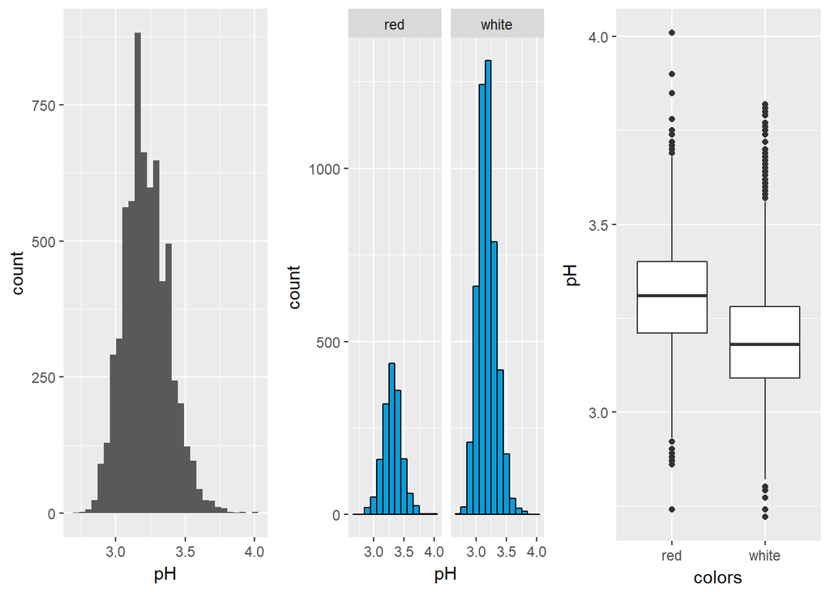

```
## df_wine$colors: red
##    Min. 1st Qu.  Median    Mean 3rd Qu.    Max.
##   2.740   3.210   3.310   3.311   3.400   4.010
## --------------------------------------------------------
## df_wine$colors: white
##    Min. 1st Qu.  Median    Mean 3rd Qu.    Max.
##   2.720   3.090   3.180   3.188   3.280   3.820
```

### So many outliers. Let’s limit the range(2.5, 3.5) for ‘pH’

## alcohol

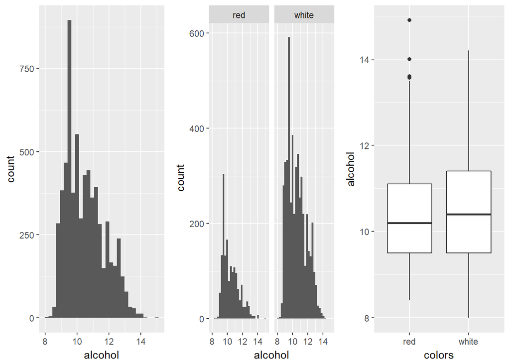

```
## df_wine$colors: red
##    Min. 1st Qu.  Median    Mean 3rd Qu.    Max.
##    8.40    9.50   10.20   10.42   11.10   14.90
## --------------------------------------------------------
## df_wine$colors: white
##    Min. 1st Qu.  Median    Mean 3rd Qu.    Max.
##    8.00    9.50   10.40   10.51   11.40   14.20
```

## total.sulfur.dioxide

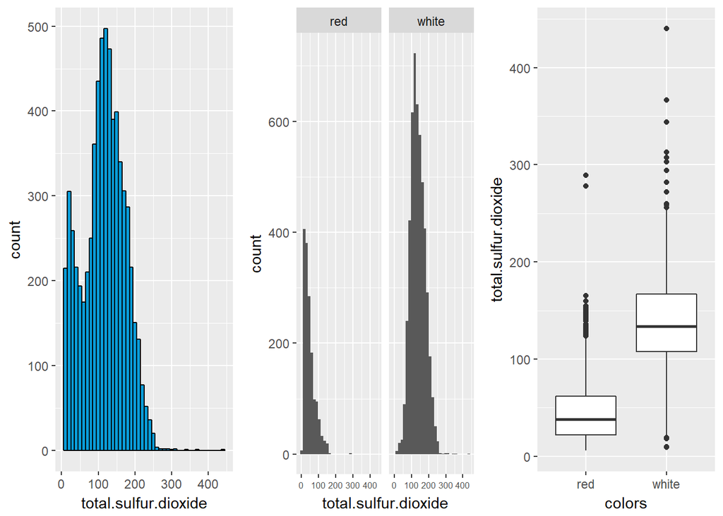

```
## df_wine$colors: red
##    Min. 1st Qu.  Median    Mean 3rd Qu.    Max.
##    6.00   22.00   38.00   46.47   62.00  289.00
## --------------------------------------------------------
## df_wine$colors: white
##    Min. 1st Qu.  Median    Mean 3rd Qu.    Max.
##     9.0   108.0   134.0   138.4   167.0   440.0
```

### The distribution of ‘total.sulfur.dioxide’ appears bimodal with the values peaking around 25 or so and again around 125. This variable measures the amount of free and bound forms of ‘S02’(as a dissolved gas) and ‘S02’ determines smell and taste of wine. This bimodal shape hints us that ‘total.sulfur.dioxide’ is the main feature distinguishes between ‘Red’ and ‘White’ wine.

### So many outliers. Let’s limit the range(5, 175) for ‘total.sulfur.dioxide’

### I want to see the plots across the categories of ‘quality’.

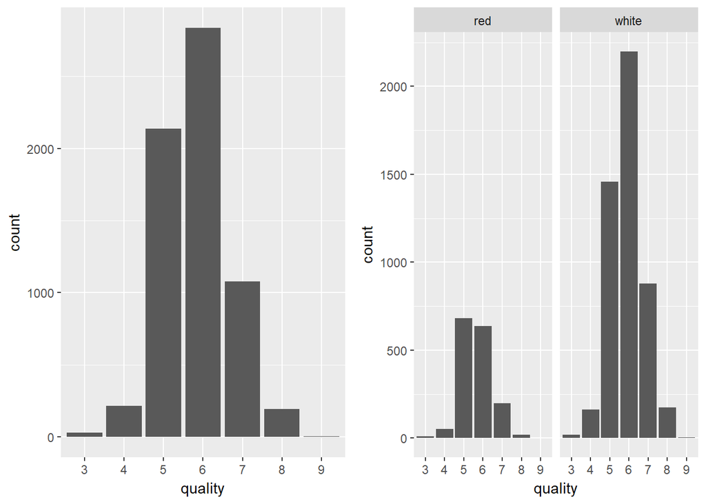

### Most of wine samples are graded around 5 to 7

# [Univariate Analysis]

### What is the structure of your dataset?

There are 6497 wine samples (red:1599, white:4898) in the dataset with 12 features describing chemical properties (fixed acidity, volatile acidity, citric acid, residual sugar, chlorides, free sulfur dioxide, total sulfur dioxide, density, pH, sulphates, alcohol, and quality). The variable ‘quality’ is an ordered factor variables with the 7 levels - 3,4,5,6,7,8,9 with 3 as the lowest and 9 as the highest.

### What is/are the main feature(s) of interest in your dataset?

We want to determine What chemical charateristics are most important in predicting the ‘quality’ of wine. Thus we need to find the main properties of wine that affect the wine ‘quality’, but it is hard to find until we proceed a series of scatter plots, t-test or ANOVA. Once we find some combinations of significant variables we can build a predictive model to grade the quality.

### What other features in the dataset do you think will help support your investigation into your feature(s) of interest?

I expect strong mulicollinearity residing within our dataset because of some connections between variables. For example, ‘pH’ variable by definition is affected by some acidity which is described by-‘fixed.acidity’, ‘volatile.acidity’, ‘citric.acid’ The variables such as ‘density’ or ‘sulphates’ also have some other variables that affect them. I think we can group them first by the connections they are related with and perform group-specific transformation prior to investigating their significance. Then we can compare mean values of variables in our interest for all samples of the each level of the quality ratings(3 to 9).

### Did you create any new variables from existing variables in the dataset?

Yes, I had to create the variable called ‘red’ to find if a certain type of wine (red or white) associated with higher quality.

### Of the features you investigated, were there any unusual distributions? Did you perform any operations on the data to tidy, adjust, or change the form of the data? If so, why did you do this?

Given that there are so many outliers found in each distribution, we’d better consider limiting the value ranges of each variable.

# [Bivariate Plots Section]

## Scator plot_01(the relationships between the predictors)

## 1) Additive and S02-gas ?

- So many outliers. Let’s limit the range to(0.2, 0.8) for ‘sulphates’
- So many outliers. Let’s limit the range to(0, 50) for ‘free.sulfur.dioxide’
- So many outliers. Let’s limit the range to(5, 175) for ‘total.sulfur.dioxide’

## 2) Wine Density(0.9~1) ?

- So many outliers. Let’s limit the range to(0.9, 1) for ‘density’
- So many outliers. Let’s limit the range to(0.5, 10) for ‘residual.sugar’
- So many outliers. Let’s limit the range to(7, 13) for ‘alcohol’

## 3) Wine pH(3~4) ?

- So many outliers. Let’s limit the range to(2.5, 3.5) for ‘pH’
- So many outliers. Let’s limit the range to(3, 10) for ‘fixed.acidity’
- So many outliers. Let’s limit the range to(0, 0.7) for ‘volatile.acidity’
- So many outliers. Let’s limit the range to(0, 0.5) for ‘citric.acid’

## 1)

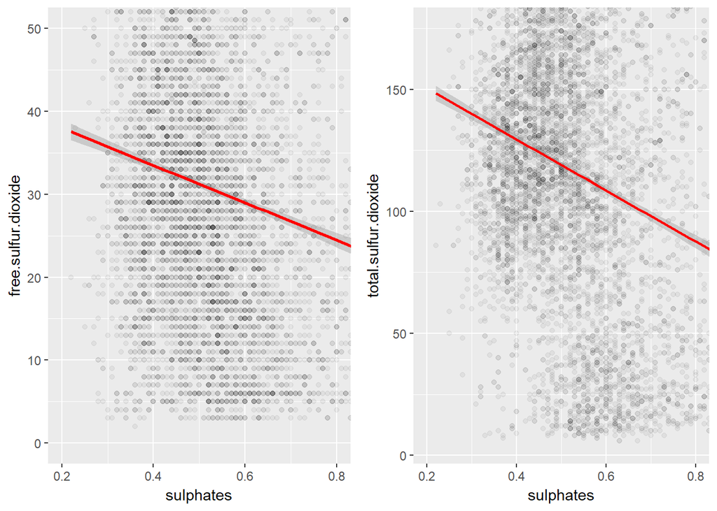

### ‘free.sulfur.dioxide’ and ‘total.sulfur.dioxide’ behave in a similar way, which makes sense because ‘free.sulfur.dioxide’ is a subset of ‘total.sulfur.dioxide’. We can expect that the sulphates(additive) takes over the role of S02-gas.

## 2)

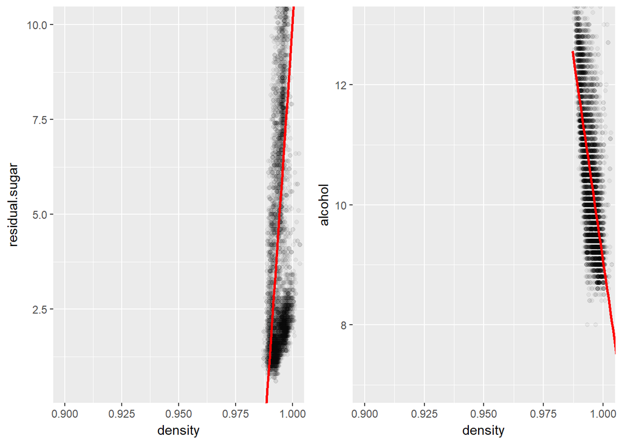

### We can see that ‘density’ is directly proportional to ‘residual.sugar’, while being inversely proportional to ‘alcohol’. We can expect that the higher sugar contents results in denser wines.

## 3)

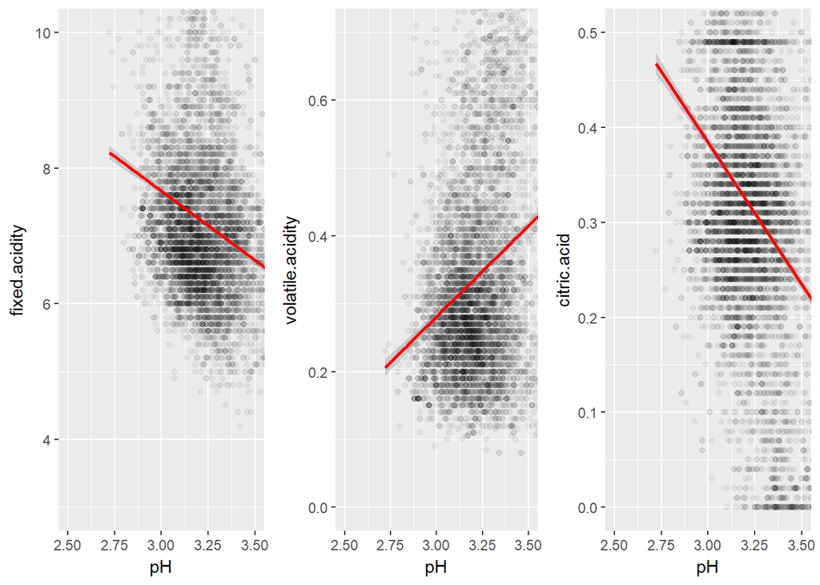

### In the same pH level, ‘fixed.acidity’ and ‘citric.acid’ behave in a similar way, but ‘volatile.acidity’ behaves opposite, which makes sense because ‘citric.acid’ is associate with ‘freshness’, while ‘volatile.acidity’ gives an unpleasant, vinegar taste.

## In this correlation matrix above, we can confirm some relations between the variables we suspect.

```
##                      fixed.acidity volatile.acidity citric.acid
## fixed.acidity           1.00000000       0.21900826  0.32443573
## volatile.acidity        0.21900826       1.00000000 -0.37798132
## citric.acid             0.32443573      -0.37798132  1.00000000
## residual.sugar         -0.11198128      -0.19601117  0.14245123
## chlorides               0.29819477       0.37712428  0.03899801
## free.sulfur.dioxide    -0.28273543      -0.35255731  0.13312581
## total.sulfur.dioxide   -0.32905390      -0.41447619  0.19524198
## density                 0.45890998       0.27129565  0.09615393
## pH                     -0.25270047       0.26145440 -0.32980819
## sulphates               0.29956774       0.22598368  0.05619730
## alcohol                -0.09545152      -0.03764039 -0.01049349
##                      residual.sugar   chlorides free.sulfur.dioxide
## fixed.acidity            -0.1119813  0.29819477         -0.28273543
## volatile.acidity         -0.1960112  0.37712428         -0.35255731
## citric.acid               0.1424512  0.03899801          0.13312581
## residual.sugar            1.0000000 -0.12894050          0.40287064
## chlorides                -0.1289405  1.00000000         -0.19504479
## free.sulfur.dioxide       0.4028706 -0.19504479          1.00000000
## total.sulfur.dioxide      0.4954816 -0.27963045          0.72093408
## density                   0.5525170  0.36261466          0.02571684
## pH                       -0.2673198  0.04470798         -0.14585390
## sulphates                -0.1859274  0.39559331         -0.18845725
## alcohol                  -0.3594148 -0.25691558         -0.17983843
##                      total.sulfur.dioxide     density          pH
## fixed.acidity                 -0.32905390  0.45890998 -0.25270047
## volatile.acidity              -0.41447619  0.27129565  0.26145440
## citric.acid                    0.19524198  0.09615393 -0.32980819
## residual.sugar                 0.49548159  0.55251695 -0.26731984
## chlorides                     -0.27963045  0.36261466  0.04470798
## free.sulfur.dioxide            0.72093408  0.02571684 -0.14585390
## total.sulfur.dioxide           1.00000000  0.03239451 -0.23841310
## density                        0.03239451  1.00000000  0.01168608
## pH                            -0.23841310  0.01168608  1.00000000
## sulphates                     -0.27572682  0.25947850  0.19212341
## alcohol                       -0.26573964 -0.68674542  0.12124847
##                         sulphates      alcohol
## fixed.acidity         0.299567744 -0.095451523
## volatile.acidity      0.225983680 -0.037640386
## citric.acid           0.056197300 -0.010493492
## residual.sugar       -0.185927405 -0.359414771
## chlorides             0.395593307 -0.256915580
## free.sulfur.dioxide  -0.188457249 -0.179838435
## total.sulfur.dioxide -0.275726820 -0.265739639
## density               0.259478495 -0.686745422
## pH                    0.192123407  0.121248467
## sulphates             1.000000000 -0.003029195
## alcohol              -0.003029195  1.000000000
```

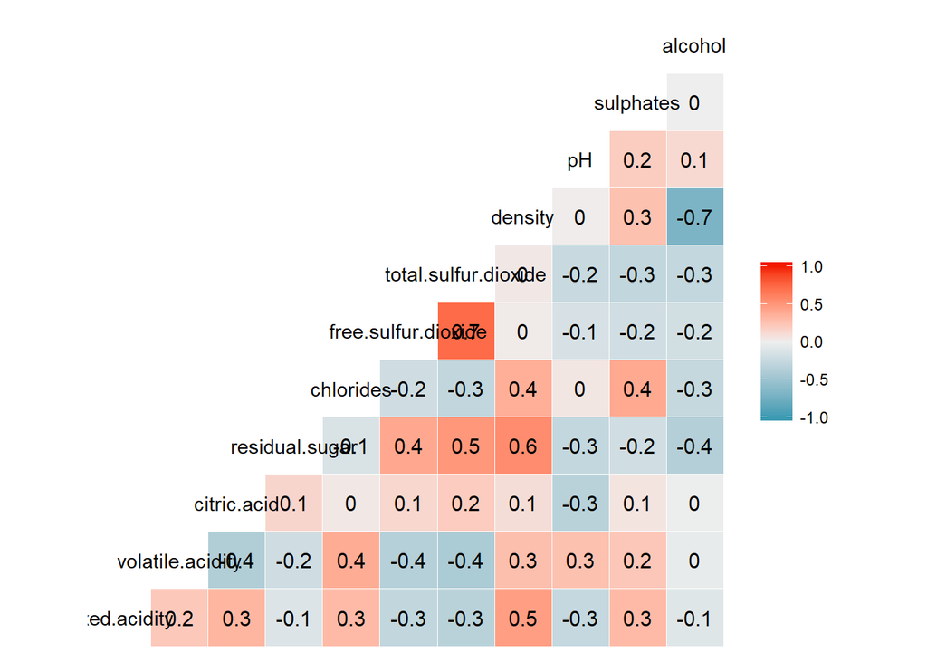

## Scator plot_02(the relationships between the response variable and the predictors)

## 1) Saltiness VS ‘quality’+‘color’ ?

- So many outliers. Let’s limit the range to(0, 0.1) for ‘chlorides’
- What’s the mean saltiness for each quality rating and color ? Are the means increase or decrease ?

## 2) Additive/S02-gas VS ‘quality’+‘color’ ?

- So many outliers. Let’s limit the range to(0.2, 0.8) for ‘sulphates’
- So many outliers. Let’s limit the range to(0, 50) for ‘free.sulfur.dioxide’
- So many outliers. Let’s limit the range to(5, 175) for ‘total.sulfur.dioxide’

## 3) Wine Density(0.9~1) VS ‘quality’+‘color’ ?

- So many outliers. Let’s limit the range to(0.9, 1) for ‘density’
- So many outliers. Let’s limit the range to(0.5, 10) for ‘residual.sugar’
- So many outliers. Let’s limit the range to(7, 13) for ‘alcohol’

## 4) Wine pH(3~4) VS ‘quality’+‘color’ ?

- So many outliers. Let’s limit the range to(2.5, 3.5) for ‘pH’
- So many outliers. Let’s limit the range to(3, 10) for ‘fixed.acidity’
- So many outliers. Let’s limit the range to(0, 0.7) for ‘volatile.acidity’
- So many outliers. Let’s limit the range to(0, 0.5) for ‘citric.acid’

## 5) alcohol VS ‘quality’+‘color’ ?

- So many outliers. Let’s limit the range to(3, 10) for ‘fixed.acidity’
- So many outliers. Let’s limit the range to(0, 0.7) for ‘volatile.acidity’
- So many outliers. Let’s limit the range to(0, 0.5) for ‘citric.acid’

## Find which predictors are significant !

## P Values

```
## Call:
## multinom(formula = quality ~ chlorides, data = df_wine)
##
## Coefficients:
##   (Intercept)   chlorides
## 4    2.290318   -4.869920
## 5    4.432330   -2.445987
## 6    5.230002  -11.279730
## 7    5.344340  -33.296037
## 8    4.393054  -51.093747
## 9    5.202887 -184.208738
##
## Std. Errors:
##   (Intercept) chlorides
## 4   0.3002849  3.310582
## 5   0.2734118  2.800124
## 6   0.2766262  2.913031
## 7   0.2898211  3.451381
## 8   0.3617003  6.108953
## 9   1.5027729 51.185995
##
## Residual Deviance: 16102.1
## AIC: 16126.1
```

```
##
## z test of coefficients:
##
##                 Estimate Std. Error z value  Pr(>|z|)
## 4:(Intercept)    2.29032    0.30028  7.6271   2.4e-14 ***
## 4:chlorides     -4.86992    3.31058 -1.4710 0.1412867
## 5:(Intercept)    4.43233    0.27341 16.2112 < 2.2e-16 ***
## 5:chlorides     -2.44599    2.80012 -0.8735 0.3823755
## 6:(Intercept)    5.23000    0.27663 18.9064 < 2.2e-16 ***
## 6:chlorides    -11.27973    2.91303 -3.8722 0.0001079 ***
## 7:(Intercept)    5.34434    0.28982 18.4401 < 2.2e-16 ***
## 7:chlorides    -33.29604    3.45138 -9.6472 < 2.2e-16 ***
## 8:(Intercept)    4.39305    0.36170 12.1456 < 2.2e-16 ***
## 8:chlorides    -51.09375    6.10895 -8.3637 < 2.2e-16 ***
## 9:(Intercept)    5.20289    1.50277  3.4622 0.0005358 ***
## 9:chlorides   -184.20874   51.18600 -3.5988 0.0003197 ***
## ---
## Signif. codes:  0 '***' 0.001 '**' 0.01 '*' 0.05 '.' 0.1 ' ' 1
```

### We are not sure how well ‘chlorides’ explains the ‘quality’. For the rating of 4 and 5, its P-values tell that ‘chlorides’ is not a significant predictor. The R2 statistic cannot be exactly computed for multinomial logistic regression models(the pseudo R-squareds with regressions of categorical outcomes are computed instead).

## P Values

```
## Call:
## multinom(formula = quality ~ colors + sulphates + free.sulfur.dioxide +
##     total.sulfur.dioxide + colors:total.sulfur.dioxide, data = df_wine)
##
## Coefficients:
##    (Intercept) colorswhite sulphates free.sulfur.dioxide
## 4   0.01795657    4.396145  1.898266        -0.085484294
## 5   1.26687379    3.088481  2.078962        -0.030875329
## 6   0.60646319    4.444835  4.000990        -0.012858241
## 7  -1.18850122    5.634609  5.494273        -0.003017241
## 8  -2.91484579    6.111370  4.574817         0.009743996
## 9 -10.17434102   11.490975  2.592305         0.009948856
##   total.sulfur.dioxide colorswhite:total.sulfur.dioxide
## 4           0.04880439                      -0.05138167
## 5           0.05833003                      -0.05685425
## 6           0.03839297                      -0.04987251
## 7           0.02377646                      -0.04594645
## 8           0.01758424                      -0.04258027
## 9           0.05343943                      -0.08444916
##
## Std. Errors:
##   (Intercept) colorswhite sulphates free.sulfur.dioxide
## 4   0.4470158   0.3529396 0.5269753         0.012157947
## 5   0.2944266   0.2224585 0.2640950         0.009903066
## 6   0.2852881   0.2120423 0.2400349         0.009788355
## 7   0.3106421   0.2403600 0.2717341         0.010050915
## 8   0.5198874   0.4368122 0.4944954         0.010914231
## 9   0.3004610   0.2984992 0.1342360         0.037659968
##   total.sulfur.dioxide colorswhite:total.sulfur.dioxide
## 4           0.01553426                       0.01358440
## 5           0.01489492                       0.01289454
## 6           0.01489705                       0.01289918
## 7           0.01511394                       0.01312570
## 8           0.01756047                       0.01571296
## 9           0.10751266                       0.10706377
##
## Residual Deviance: 15687.28
## AIC: 15759.28
```

```
##
## z test of coefficients:
##
##                                       Estimate  Std. Error  z value
## 4:(Intercept)                        0.0179566   0.4470158   0.0402
## 4:colorswhite                        4.3961448   0.3529396  12.4558
## 4:sulphates                          1.8982656   0.5269753   3.6022
## 4:free.sulfur.dioxide               -0.0854843   0.0121579  -7.0311
## 4:total.sulfur.dioxide               0.0488044   0.0155343   3.1417
## 4:colorswhite:total.sulfur.dioxide  -0.0513817   0.0135844  -3.7824
## 5:(Intercept)                        1.2668738   0.2944266   4.3029
## 5:colorswhite                        3.0884811   0.2224585  13.8834
## 5:sulphates                          2.0789620   0.2640950   7.8720
## 5:free.sulfur.dioxide               -0.0308753   0.0099031  -3.1178
## 5:total.sulfur.dioxide               0.0583300   0.0148949   3.9161
## 5:colorswhite:total.sulfur.dioxide  -0.0568542   0.0128945  -4.4092
## 6:(Intercept)                        0.6064632   0.2852881   2.1258
## 6:colorswhite                        4.4448348   0.2120423  20.9620
## 6:sulphates                          4.0009895   0.2400349  16.6684
## 6:free.sulfur.dioxide               -0.0128582   0.0097884  -1.3136
## 6:total.sulfur.dioxide               0.0383930   0.0148970   2.5772
## 6:colorswhite:total.sulfur.dioxide  -0.0498725   0.0128992  -3.8663
## 7:(Intercept)                       -1.1885012   0.3106421  -3.8259
## 7:colorswhite                        5.6346094   0.2403600  23.4424
## 7:sulphates                          5.4942734   0.2717341  20.2193
## 7:free.sulfur.dioxide               -0.0030172   0.0100509  -0.3002
## 7:total.sulfur.dioxide               0.0237765   0.0151139   1.5731
## 7:colorswhite:total.sulfur.dioxide  -0.0459464   0.0131257  -3.5005
## 8:(Intercept)                       -2.9148458   0.5198874  -5.6067
## 8:colorswhite                        6.1113699   0.4368122  13.9908
## 8:sulphates                          4.5748173   0.4944954   9.2515
## 8:free.sulfur.dioxide                0.0097440   0.0109142   0.8928
## 8:total.sulfur.dioxide               0.0175842   0.0175605   1.0014
## 8:colorswhite:total.sulfur.dioxide  -0.0425803   0.0157130  -2.7099
## 9:(Intercept)                      -10.1743410   0.3004610 -33.8624
## 9:colorswhite                       11.4909749   0.2984992  38.4958
## 9:sulphates                          2.5923051   0.1342360  19.3115
## 9:free.sulfur.dioxide                0.0099489   0.0376600   0.2642
## 9:total.sulfur.dioxide               0.0534394   0.1075127   0.4971
## 9:colorswhite:total.sulfur.dioxide  -0.0844492   0.1070638  -0.7888
```

[output cut: 24 more lines]

```
## 7:colorswhite:total.sulfur.dioxide 0.0004644 ***
## 8:(Intercept)                      2.062e-08 ***
## 8:colorswhite                      < 2.2e-16 ***
## 8:sulphates                        < 2.2e-16 ***
## 8:free.sulfur.dioxide              0.3719756
## 8:total.sulfur.dioxide             0.3166560
## 8:colorswhite:total.sulfur.dioxide 0.0067307 **
## 9:(Intercept)                      < 2.2e-16 ***
## 9:colorswhite                      < 2.2e-16 ***
## 9:sulphates                        < 2.2e-16 ***
## 9:free.sulfur.dioxide              0.7916444
## 9:total.sulfur.dioxide             0.6191521
## 9:colorswhite:total.sulfur.dioxide 0.4302439
## ---
## Signif. codes:  0 '***' 0.001 '**' 0.01 '*' 0.05 '.' 0.1 ' ' 1
```

## P Values

```
## Call:
## multinom(formula = quality ~ density * residual.sugar + density *
##     alcohol, data = df_wine)
##
## Coefficients:
##   (Intercept)     density residual.sugar   alcohol density:residual.sugar
## 4    5.637276   0.4534752     -3.5783734 17.283559              3.5501333
## 5   13.669815  -3.1218071     -0.5393417  9.379759              0.5524923
## 6    8.495589  -6.2716443     -1.2413149 16.677448              1.3299013
## 7   -9.116425   4.3245729     -0.9216359 21.488331              1.0367753
## 8   -5.130051  -3.0891728      1.0730485 32.630747             -0.8644032
## 9   -7.063355 -10.3322658     -0.6983118 24.158599              0.8515190
##   density:alcohol
## 4       -17.75467
## 5       -10.05770
## 6       -16.58319
## 7       -20.87751
## 8       -32.00519
## 9       -22.97598
##
## Std. Errors:
##   (Intercept)  density residual.sugar   alcohol density:residual.sugar
## 4    1.241577 1.150299      3.5542812 2.9379105              3.5635548
## 5    1.105559 1.087219      2.1416905 1.6263874              2.1444260
## 6    1.090053 1.082791      1.5994437 1.3947039              1.5997992
## 7    1.111587 1.090934      1.6966185 1.6543011              1.6979615
## 8    1.275975 1.165422      3.9070594 3.5026056              3.9269234
## 9    2.951866 2.969271      0.1931955 0.4691374              0.1801502
##   density:alcohol
## 4       2.9917651
## 5       1.6457713
## 6       1.4108300
## 7       1.6783506
## 8       3.5699628
## 9       0.0460735
##
## Residual Deviance: 14707.29
## AIC: 14779.29
```

```
##
## z test of coefficients:
##
##                            Estimate Std. Error   z value  Pr(>|z|)
## 4:(Intercept)              5.637276   1.241577    4.5404 5.614e-06 ***
## 4:density                  0.453475   1.150299    0.3942 0.6934157
## 4:residual.sugar          -3.578373   3.554281   -1.0068 0.3140413
## 4:alcohol                 17.283559   2.937910    5.8829 4.030e-09 ***
## 4:density:residual.sugar   3.550133   3.563555    0.9962 0.3191366
## 4:density:alcohol        -17.754671   2.991765   -5.9345 2.947e-09 ***
## 5:(Intercept)             13.669815   1.105559   12.3646 < 2.2e-16 ***
## 5:density                 -3.121807   1.087219   -2.8714 0.0040870 **
## 5:residual.sugar          -0.539342   2.141691   -0.2518 0.8011725
## 5:alcohol                  9.379759   1.626387    5.7672 8.058e-09 ***
## 5:density:residual.sugar   0.552492   2.144426    0.2576 0.7966839
## 5:density:alcohol        -10.057704   1.645771   -6.1112 9.886e-10 ***
## 6:(Intercept)              8.495589   1.090053    7.7937 6.505e-15 ***
## 6:density                 -6.271644   1.082791   -5.7921 6.951e-09 ***
## 6:residual.sugar          -1.241315   1.599444   -0.7761 0.4376949
## 6:alcohol                 16.677448   1.394704   11.9577 < 2.2e-16 ***
## 6:density:residual.sugar   1.329901   1.599799    0.8313 0.4058083
## 6:density:alcohol        -16.583193   1.410830  -11.7542 < 2.2e-16 ***
## 7:(Intercept)             -9.116425   1.111587   -8.2013 2.379e-16 ***
## 7:density                  4.324573   1.090934    3.9641 7.367e-05 ***
## 7:residual.sugar          -0.921636   1.696619   -0.5432 0.5869788
## 7:alcohol                 21.488331   1.654301   12.9894 < 2.2e-16 ***
## 7:density:residual.sugar   1.036775   1.697962    0.6106 0.5414644
## 7:density:alcohol        -20.877506   1.678351  -12.4393 < 2.2e-16 ***
## 8:(Intercept)             -5.130051   1.275975   -4.0205 5.808e-05 ***
## 8:density                 -3.089173   1.165422   -2.6507 0.0080327 **
## 8:residual.sugar           1.073049   3.907059    0.2746 0.7835901
## 8:alcohol                 32.630747   3.502606    9.3161 < 2.2e-16 ***
## 8:density:residual.sugar  -0.864403   3.926923   -0.2201 0.8257760
## 8:density:alcohol        -32.005186   3.569963   -8.9651 < 2.2e-16 ***
## 9:(Intercept)             -7.063355   2.951866   -2.3928 0.0167183 *
## 9:density                -10.332266   2.969271   -3.4797 0.0005019 ***
## 9:residual.sugar          -0.698312   0.193195   -3.6145 0.0003009 ***
## 9:alcohol                 24.158599   0.469137   51.4958 < 2.2e-16 ***
## 9:density:residual.sugar   0.851519   0.180150    4.7267 2.282e-06 ***
## 9:density:alcohol        -22.975976   0.046073 -498.6810 < 2.2e-16 ***
## ---
## Signif. codes:  0 '***' 0.001 '**' 0.01 '*' 0.05 '.' 0.1 ' ' 1
```

### As seen above, ‘alcohol’ shows the greatest significance.

## P Values

```
## Call:
## multinom(formula = quality ~ pH + pH * fixed.acidity + pH * volatile.acidity +
##     pH * citric.acid + fixed.acidity * citric.acid, data = df_wine)
##
## Coefficients:
##   (Intercept)         pH fixed.acidity volatile.acidity citric.acid
## 4   9.5555601 -0.8925939    -2.8758956        27.740237   19.072200
## 5  15.2956613 -2.5388650    -3.8612235        32.183042   21.382671
## 6  21.6314914 -3.9096006    -3.7736870         9.731153    9.933412
## 7  19.5122447 -2.8152304    -2.8186785         3.614491  -13.004315
## 8  11.8170371 -0.3149329    -0.4554982         7.514177  -38.446022
## 9  -0.3938688 -0.9637132    -2.4427135        -1.503990    2.213982
##   pH:fixed.acidity pH:volatile.acidity pH:citric.acid
## 4        0.6942788           -8.425932      -7.918038
## 5        1.1081988          -10.333240      -7.097463
## 6        1.0681529           -4.511709      -4.206871
## 7        0.6802230           -3.050877       1.517189
## 8       -0.1764845           -3.826516       9.197297
## 9        0.8981282           -1.533613       1.880776
##   fixed.acidity:citric.acid
## 4                 0.8151785
## 5                 0.2002372
## 6                 0.4613086
## 7                 1.1388018
## 8                 1.3414699
## 9                -0.8278455
##
## Std. Errors:
##   (Intercept)        pH fixed.acidity volatile.acidity citric.acid
## 4    2.243644 0.8940557     0.7585560        3.8480882    2.383343
## 5    3.446056 1.1545557     0.7608927        3.1178480    3.730217
## 6    3.194696 1.0874409     0.7436089        3.0715204    3.494662
## 7    3.703987 1.2155527     0.8168188        4.0107774    4.170194
## 8    3.466305 1.2154212     0.9221649        1.5092790    1.412335
## 9    0.482554 2.0802956     1.6119520        0.3293711    1.091527
##   pH:fixed.acidity pH:volatile.acidity pH:citric.acid
## 4        0.2501792           1.1818101       1.375286
## 5        0.2480755           0.9784349       1.595295
## 6        0.2431228           0.9653746       1.544650
## 7        0.2634968           1.2476185       1.697342
## 8        0.2977400           0.5557463       1.386925
## 9        0.4795112           1.0041201       4.425760
##   fixed.acidity:citric.acid
## 4                 0.5467959
## 5                 0.5150492
## 6                 0.5153872
## 7                 0.5257805
## 8                 0.5941765
## 9                 2.1744720
##
## Residual Deviance: 15831.19
## AIC: 15939.19
```

```
##
## z test of coefficients:
##
##                              Estimate Std. Error  z value  Pr(>|z|)
## 4:(Intercept)                 9.55556    2.24364   4.2589 2.054e-05 ***
## 4:pH                         -0.89259    0.89406  -0.9984 0.3181024
## 4:fixed.acidity              -2.87590    0.75856  -3.7913 0.0001499 ***
## 4:volatile.acidity           27.74024    3.84809   7.2088 5.643e-13 ***
## 4:citric.acid                19.07220    2.38334   8.0023 1.221e-15 ***
## 4:pH:fixed.acidity            0.69428    0.25018   2.7751 0.0055180 **
## 4:pH:volatile.acidity        -8.42593    1.18181  -7.1297 1.006e-12 ***
## 4:pH:citric.acid             -7.91804    1.37529  -5.7574 8.543e-09 ***
## 4:fixed.acidity:citric.acid   0.81518    0.54680   1.4908 0.1360067
## 5:(Intercept)                15.29566    3.44606   4.4386 9.055e-06 ***
## 5:pH                         -2.53887    1.15456  -2.1990 0.0278781 *
## 5:fixed.acidity              -3.86122    0.76089  -5.0746 3.883e-07 ***
## 5:volatile.acidity           32.18304    3.11785  10.3222 < 2.2e-16 ***
## 5:citric.acid                21.38267    3.73022   5.7323 9.909e-09 ***
## 5:pH:fixed.acidity            1.10820    0.24808   4.4672 7.926e-06 ***
## 5:pH:volatile.acidity       -10.33324    0.97843 -10.5610 < 2.2e-16 ***
## 5:pH:citric.acid             -7.09746    1.59530  -4.4490 8.627e-06 ***
## 5:fixed.acidity:citric.acid   0.20024    0.51505   0.3888 0.6974441
## 6:(Intercept)                21.63149    3.19470   6.7711 1.278e-11 ***
## 6:pH                         -3.90960    1.08744  -3.5952 0.0003241 ***
## 6:fixed.acidity              -3.77369    0.74361  -5.0748 3.878e-07 ***
## 6:volatile.acidity            9.73115    3.07152   3.1682 0.0015339 **
## 6:citric.acid                 9.93341    3.49466   2.8425 0.0044768 **
## 6:pH:fixed.acidity            1.06815    0.24312   4.3935 1.116e-05 ***
## 6:pH:volatile.acidity        -4.51171    0.96537  -4.6735 2.961e-06 ***
## 6:pH:citric.acid             -4.20687    1.54465  -2.7235 0.0064592 **
## 6:fixed.acidity:citric.acid   0.46131    0.51539   0.8951 0.3707486
## 7:(Intercept)                19.51224    3.70399   5.2679 1.380e-07 ***
## 7:pH                         -2.81523    1.21555  -2.3160 0.0205578 *
## 7:fixed.acidity              -2.81868    0.81682  -3.4508 0.0005589 ***
## 7:volatile.acidity            3.61449    4.01078   0.9012 0.3674849
## 7:citric.acid               -13.00431    4.17019  -3.1184 0.0018184 **
## 7:pH:fixed.acidity            0.68022    0.26350   2.5815 0.0098365 **
## 7:pH:volatile.acidity        -3.05088    1.24762  -2.4454 0.0144708 *
## 7:pH:citric.acid              1.51719    1.69734   0.8939 0.3713957
## 7:fixed.acidity:citric.acid   1.13880    0.52578   2.1659 0.0303168 *
## 8:(Intercept)                11.81704    3.46630   3.4091 0.0006517 ***
## 8:pH                         -0.31493    1.21542  -0.2591 0.7955471
## 8:fixed.acidity              -0.45550    0.92216  -0.4939 0.6213454
## 8:volatile.acidity            7.51418    1.50928   4.9787 6.403e-07 ***
## 8:citric.acid               -38.44602    1.41234 -27.2216 < 2.2e-16 ***
## 8:pH:fixed.acidity           -0.17648    0.29774  -0.5927 0.5533505
## 8:pH:volatile.acidity        -3.82652    0.55575  -6.8854 5.764e-12 ***
## 8:pH:citric.acid              9.19730    1.38693   6.6314 3.325e-11 ***
## 8:fixed.acidity:citric.acid   1.34147    0.59418   2.2577 0.0239646 *
## 9:(Intercept)                -0.39387    0.48255  -0.8162 0.4143761
## 9:pH                         -0.96371    2.08030  -0.4633 0.6431796
## 9:fixed.acidity              -2.44271    1.61195  -1.5154 0.1296772
## 9:volatile.acidity           -1.50399    0.32937  -4.5662 4.965e-06 ***
## 9:citric.acid                 2.21398    1.09153   2.0283 0.0425261 *
## 9:pH:fixed.acidity            0.89813    0.47951   1.8730 0.0610673 .
## 9:pH:volatile.acidity        -1.53361    1.00412  -1.5273 0.1266814
## 9:pH:citric.acid              1.88078    4.42576   0.4250 0.6708650
## 9:fixed.acidity:citric.acid  -0.82785    2.17447  -0.3807 0.7034177
## ---
## Signif. codes:  0 '***' 0.001 '**' 0.01 '*' 0.05 '.' 0.1 ' ' 1
```

### Here ‘citric.acid’ shows the greatest significance.

## Now, look at how the categorical features of ‘quality’ vary with 4 different selected predictors - chlorides, sulphates, alcohol, citric.acid.

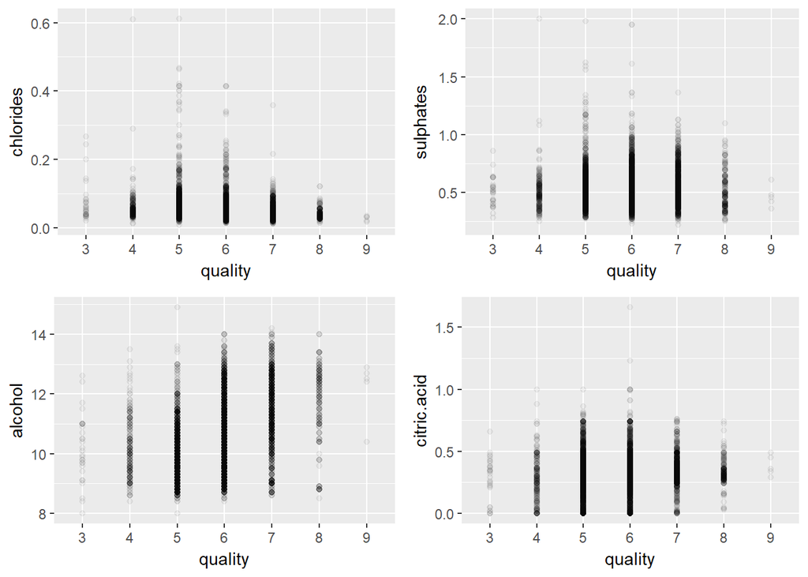

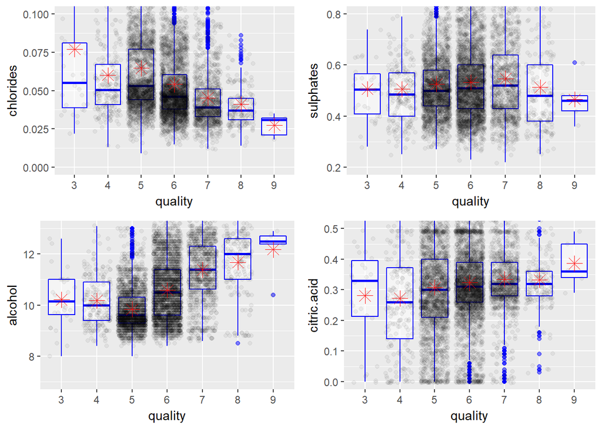

### ‘alcohol’ definitely most likely to have a positive impact on ‘quality’. But it seems also worth investigating ‘chlorides’, ‘sulphates’ and ‘citric.acid’ further.

# > Q1.“Is a certain type of wine (red or white) associated with the wine quality?”(Groupying by the CATEGORICAL)

### Compute the mean quality by colors.

```
## df_wine$colors: red
## [1] 5.636023
## --------------------------------------------------------
## df_wine$colors: white
## [1] 5.877909
```

### We can see there is a small difference in their mean-qualities of wine. Let’s delve into each property. Note: To find the mean-quality rating, we need to unfactor ‘quality’ because we cannot calculate the aggregation with a factor.

## 1. chlorides

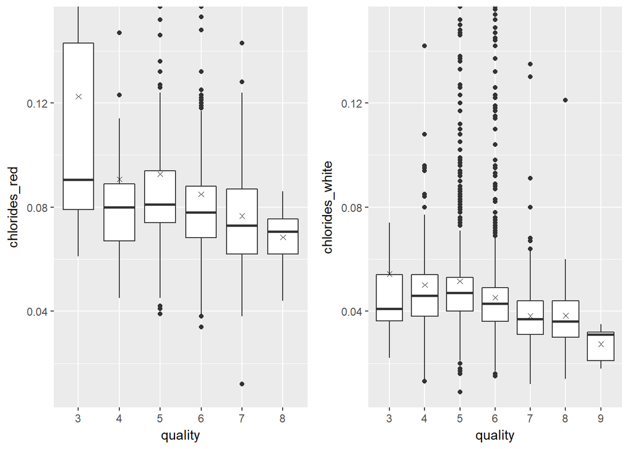

```
## # A tibble: 13 x 7
## # Groups:   quality [?]
##    quality colors mean_chlorides median_chlorides up_quantile low_quantile
##    <fct>   <fct>           <dbl>            <dbl>       <dbl>        <dbl>
##  1 3       red            0.122            0.0905      0.143        0.0790
##  2 3       white          0.0543           0.0410      0.0540       0.0362
##  3 4       red            0.0907           0.0800      0.0890       0.0670
##  4 4       white          0.0501           0.0460      0.0540       0.0380
##  5 5       red            0.0927           0.0810      0.0940       0.0740
##  6 5       white          0.0515           0.0470      0.0530       0.0400
##  7 6       red            0.0850           0.0780      0.0880       0.0682
##  8 6       white          0.0452           0.0430      0.0490       0.0360
##  9 7       red            0.0766           0.0730      0.0870       0.0620
## 10 7       white          0.0382           0.0370      0.0440       0.0310
## 11 8       red            0.0684           0.0705      0.0755       0.0620
## 12 8       white          0.0383           0.0360      0.0440       0.0300
## 13 9       white          0.0274           0.0310      0.0320       0.0210
## # ... with 1 more variable: n <int>
```

### Seemingly, in both red and white wine, the samples get higher rated as the amount of ‘chlorides’ decrease. So a good wine might not be salty. ‘Colors’ is not a game changer here.

## 2. sulphates

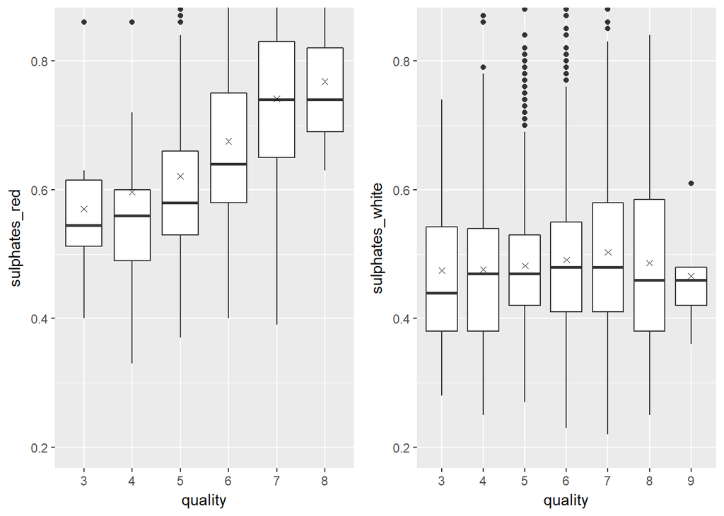

```
## # A tibble: 13 x 7
## # Groups:   quality [?]
##    quality colors mean_sulphates median_sulphates up_quantile low_quantile
##    <fct>   <fct>           <dbl>            <dbl>       <dbl>        <dbl>
##  1 3       red             0.570            0.545       0.615        0.512
##  2 3       white           0.475            0.440       0.542        0.380
##  3 4       red             0.596            0.560       0.600        0.490
##  4 4       white           0.476            0.470       0.540        0.380
##  5 5       red             0.621            0.580       0.660        0.530
##  6 5       white           0.482            0.470       0.530        0.420
##  7 6       red             0.675            0.640       0.750        0.580
##  8 6       white           0.491            0.480       0.550        0.410
##  9 7       red             0.741            0.740       0.830        0.650
## 10 7       white           0.503            0.480       0.580        0.410
## 11 8       red             0.768            0.740       0.820        0.690
## 12 8       white           0.486            0.460       0.585        0.380
## 13 9       white           0.466            0.460       0.480        0.420
## # ... with 1 more variable: n <int>
```

### Seemingly, only in red wine, as the additive(sulphates) increases, the samples get higher rated, but this does not hold true in white wine; therefore, ‘colors’ is suspected of a certain relationship with the quality rating. The additive does not work in white wine.

## 3. alcohol

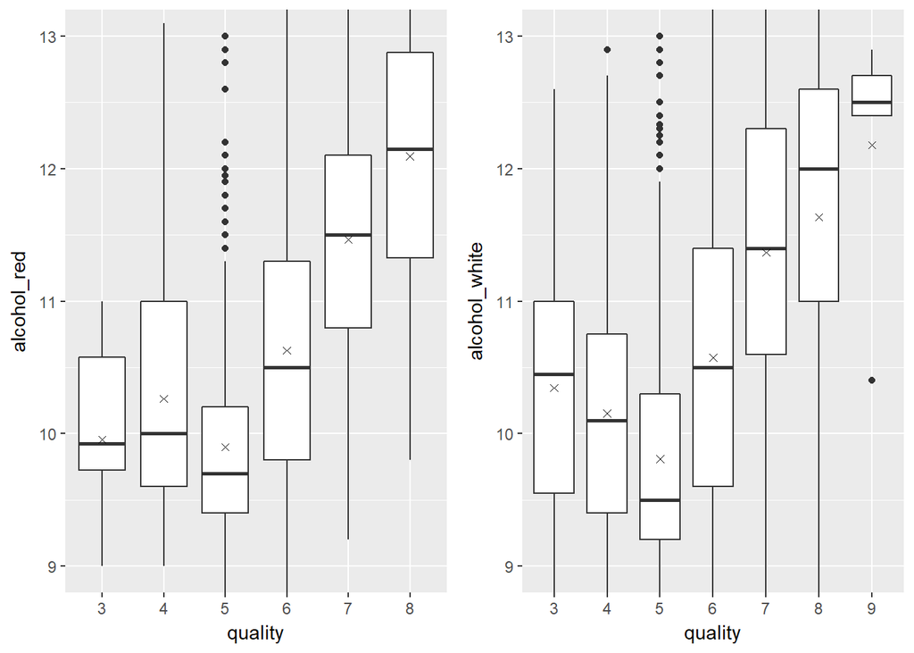

```
## # A tibble: 13 x 7
## # Groups:   quality [?]
##    quality colors mean_alcohol median_alcohol up_quantile low_quantile
##    <fct>   <fct>         <dbl>          <dbl>       <dbl>        <dbl>
##  1 3       red            9.96           9.93        10.6         9.72
##  2 3       white         10.3           10.4         11.0         9.55
##  3 4       red           10.3           10.0         11.0         9.60
##  4 4       white         10.2           10.1         10.8         9.40
##  5 5       red            9.90           9.70        10.2         9.40
##  6 5       white          9.81           9.50        10.3         9.20
##  7 6       red           10.6           10.5         11.3         9.80
##  8 6       white         10.6           10.5         11.4         9.60
##  9 7       red           11.5           11.5         12.1        10.8
## 10 7       white         11.4           11.4         12.3        10.6
## 11 8       red           12.1           12.2         12.9        11.3
## 12 8       white         11.6           12.0         12.6        11.0
## 13 9       white         12.2           12.5         12.7        12.4
## # ... with 1 more variable: n <int>
```

### Interestingly, in both red and white wine, the quality range from 5 to 9 is hugely affected by the amount of alcohol. As the amount of alcohol increases, the samples get higher rated. Here, ‘colors’ does not make any difference.

# > Q2. By the way, do really wines with higher alcoholic content receive better ratings? (Groupying by SPLITTING the dataset)

### We’ve suspected that ‘alcohol’ is the most distinguishable property that affect the quality rating. To in vestigate further, we organize two groups of wine samples:

- low.alcohol(less than the median)
- high.alcohol(greater than or equal to the median)

### Then, find the mean-quality rating of each group.

### First, get the median amount of alcohol content: 10.3, then select samples with alcohol content less than the median, and greater than or equal to the median. Lastly, get the mean-quality rating for the low alcohol and high alcohol groups.

```
## [1] 10.3
```

```
## [1] NA
```

```
## [1] NA
```

### Create a bar chart of the mean quality with one bar for low alcohol and one bar for high alcohol wine samples.

```
## [1] "data.frame"
```

```
## 'data.frame':    6497 obs. of  2 variables:
##  $ alcohol: Factor w/ 2 levels "low","high": 1 1 1 1 1 1 1 1 1 1 ...
##  $ rating : num  4 3 4 3 3 4 4 4 4 3 ...
```

[figure not shown]

## It is apparent that wines with higher alcoholic content receive better ratings in general.

## 4. citric.acid

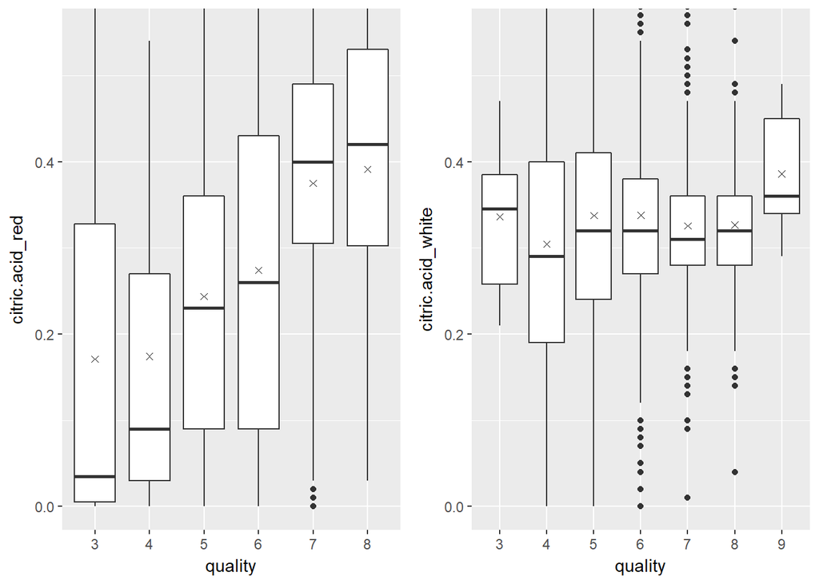

```
## # A tibble: 13 x 7
## # Groups:   quality [?]
##    quality colors mean_citric.acid median_citric.acid up_quantile
##    <fct>   <fct>             <dbl>              <dbl>       <dbl>
##  1 3       red               0.171             0.0350       0.328
##  2 3       white             0.336             0.345        0.385
##  3 4       red               0.174             0.0900       0.270
##  4 4       white             0.304             0.290        0.400
##  5 5       red               0.244             0.230        0.360
##  6 5       white             0.338             0.320        0.410
##  7 6       red               0.274             0.260        0.430
##  8 6       white             0.338             0.320        0.380
##  9 7       red               0.375             0.400        0.490
## 10 7       white             0.326             0.310        0.360
## 11 8       red               0.391             0.420        0.530
## 12 8       white             0.327             0.320        0.360
## 13 9       white             0.386             0.360        0.450
## # ... with 2 more variables: low_quantile <dbl>, n <int>
```

### Seemingly, only in red wine, the quality rating is affected by the amount of citric.acid. As the citric.acid increases, the samples get higher rated.

## Judging from the series of the plots above, ‘colors’ of wine (red or white) is somewhat associated with quality-rating when it comes to a certain properties such as ‘sulphates’ and ‘citric.acid’.

## Seemingly, in red wine, more ‘sulphates’ and ‘citric.acid’ help higher ratings.

# > Q3.“What level of acidity (pH value) receives the highest average rating?”(Groupying by the NUMERICAL)

### Unlike color, which has clear categories, pH is a quantitative variable without clear categories. Let’s create our own categories.

### Acidity Levels:

- Very_High: Lowest 25% of pH values
- High: 25% - 50% of pH values
- Medium: 50% - 75% of pH values
- Low: 75% - max pH value

### First, let’s View the min, 25%, 50%, 75%, max pH values to find ‘bin-edges’.

```
##    Min. 1st Qu.  Median    Mean 3rd Qu.    Max.
##   2.720   3.110   3.210   3.219   3.320   4.010
```

### Labels for the four acidity level groups - min/25%/50%/75%/max and find the mean quality rating of each pH level.

```
##
## very_high      high    medium       low      <NA>
##      1717      1643      1562      1574         1
```

### We found one NA that is not classified by any pH level.

```
## df_wine$pH.bucket: very_high
## [1] 5.783343
## --------------------------------------------------------
## df_wine$pH.bucket: high
## [1] 5.78454
## --------------------------------------------------------
## df_wine$pH.bucket: medium
## [1] 5.850832
## --------------------------------------------------------
## df_wine$pH.bucket: low
## [1] 5.859593
```

### Create a bar chart with a bar for each of the 4 acidity levels.

```
## df_wine$pH.bucket: very_high
## [1] 5.783343
## --------------------------------------------------------
## df_wine$pH.bucket: high
## [1] 5.78454
## --------------------------------------------------------
## df_wine$pH.bucket: medium
## [1] 5.850832
## --------------------------------------------------------
## df_wine$pH.bucket: low
## [1] 5.859593
```

```
## # A tibble: 9 x 4
## # Groups:   pH.bucket [?]
##   pH.bucket colors mean_qual     n
##   <fct>     <fct>      <dbl> <int>
## 1 very_high red         5.69   143
## 2 very_high white       5.79  1574
## 3 high      red         5.68   281
## 4 high      white       5.81  1362
## 5 medium    red         5.67   443
## 6 medium    white       5.92  1119
## 7 low       red         5.59   732
## 8 low       white       6.10   842
## 9 <NA>      white       6.00     1
```

```
##   pH.bucket      red    white
## 1 very_high 5.692308 5.791614
## 2      high 5.676157 5.806902
## 3    medium 5.670429 5.922252
## 4       low 5.588798 6.095012
## 5      <NA>      NaN 6.000000
```

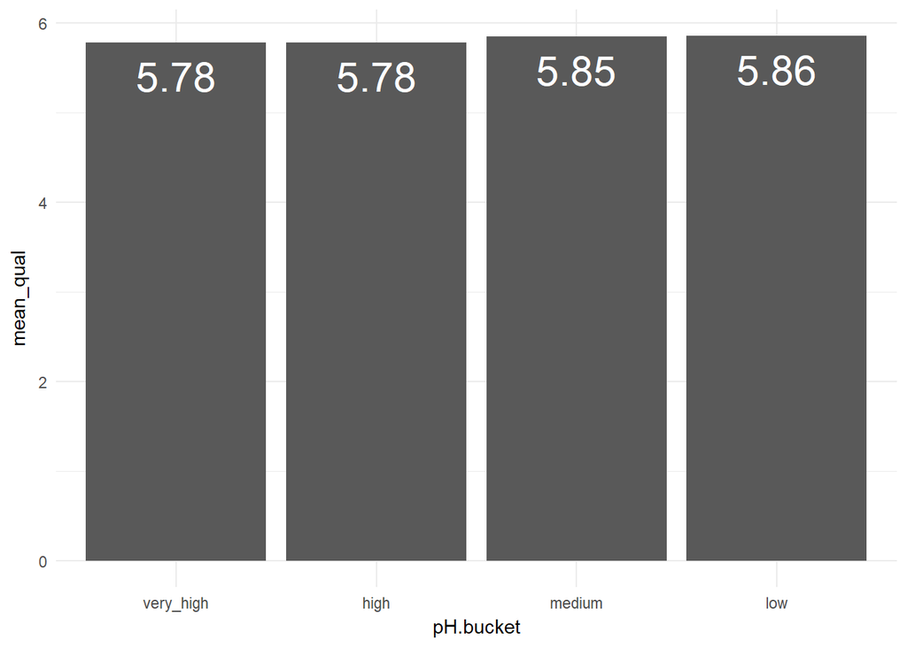

### Seemingly there is no outstanding difference in quality rating between different pH levels.

# [Multivariate Plots Section]

### From Q1. But I’d like to get more details on where the difference of mean-quality is coming from. Is it from ‘colors’? First, I plot the counts of red/white by each quality. In higher quality, which one is dominant?

```
## # A tibble: 13 x 14
## # Groups:   quality [?]
##    quality colors fixed.acidity volatile.acidity citric.acid
##      <dbl> <fct>          <int>            <int>       <int>
##  1    3.00 red               10               10          10
##  2    3.00 white             20               20          20
##  3    4.00 red               53               53          53
##  4    4.00 white            163              163         163
##  5    5.00 red              681              681         681
##  6    5.00 white           1457             1457        1457
##  7    6.00 red              638              638         638
##  8    6.00 white           2198             2198        2198
##  9    7.00 red              199              199         199
## 10    7.00 white            880              880         880
## 11    8.00 red               18               18          18
## 12    8.00 white            175              175         175
## 13    9.00 white              5                5           5
## # ... with 9 more variables: residual.sugar <int>, chlorides <int>,
## #   free.sulfur.dioxide <int>, total.sulfur.dioxide <int>, density <int>,
## #   pH <int>, sulphates <int>, alcohol <int>, n <int>
```

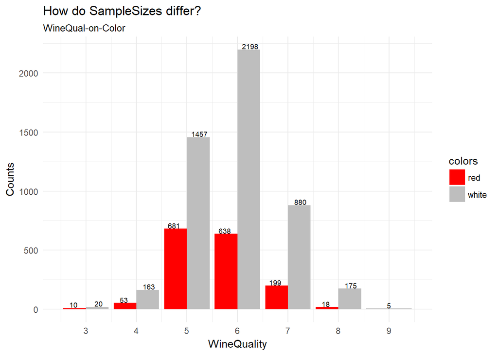

### There are clearly more white samples than red samples. so it’s hard to make a fair comparison. To balance this out, we can divide each count by the total count for that color to use “proportions” instead. Note: there is no red sample on the wine quality 9.

```
## # A tibble: 13 x 5
## # Groups:   quality [?]
##    quality colors fixed.acidity    pH     n
##      <dbl> <fct>          <int> <int> <int>
##  1    3.00 red               10    10    10
##  2    3.00 white             20    20    20
##  3    4.00 red               53    53    53
##  4    4.00 white            163   163   163
##  5    5.00 red              681   681   681
##  6    5.00 white           1457  1457  1457
##  7    6.00 red              638   638   638
##  8    6.00 white           2198  2198  2198
##  9    7.00 red              199   199   199
## 10    7.00 white            880   880   880
## 11    8.00 red               18    18    18
## 12    8.00 white            175   175   175
## 13    9.00 white              5     5     5
```

```
## # A tibble: 2 x 4
##   colors fixed.acidity_t  pH_t   n_t
##   <fct>            <int> <int> <int>
## 1 red               1599  1599  1599
## 2 white             4898  4898  4898
```

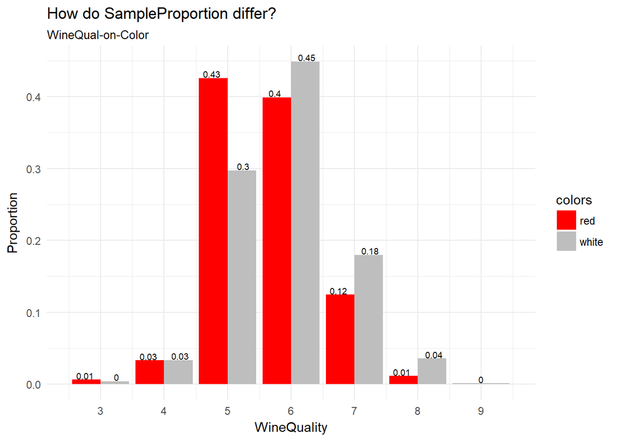

### From Q3. Then I’d like to see the behavour of the mean-citric.acid, the mean-fixed.acidity, and the mean-volatile.acidity of each pH level by different quality ratings. This is because they all influence the pH level in a different way and I want to compare the behavior of ‘citric.acid’(which I consider significant) with the rest of this group. A line plot here is not appropriate to depict the relation between quality and other features since the data is noisy, it is not clear if the separation is significant.

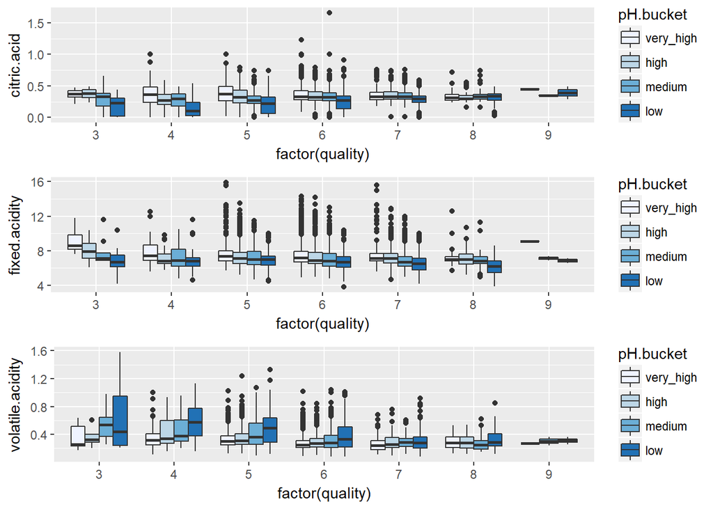

### Seemingly, in order to get higher rated, one needs to keep an enough amount of ‘citric.acid’ and ‘fixed.acidity’ with the moderately high pH-level(3.11 ~ 3.21)

# [Bivariate Analysis + Multivariate Analysis]

## 1.Bivariate Analysis

### Talk about some of the relationships you observed in this part of the investigation. How did the feature(s) of interest vary with other features in the dataset?

Before proceeding EDA, I tried to understand what the given variables talk about. Our variables can be broken into 4 different groups that are describing - 1)Saltiness, 2)S02 gas, 3)Wine Density, 4)Acidity. I investigated the relationships of variables, considering where they belong to. From a series of scatter plots, I could reaffirm my understanding of these grouping.

> First, there is no other variables but ‘chlorides’ that explaing saltiness.

> Second, between variables associated with S02 gas, I could see that ‘free.sulfur.dioxide’ is a subset of ‘total.sulfur.dioxide’ and the sulphates(additives) is replacing the role of these S02 gas. As pointed out above, ‘total.sulfur.dioxide’ is the main feature distinguishes between ‘Red’ and ‘White’ wine; therefore, we need to consider a serious interaction between the nemerical ‘total.sulfur.dioxide’ and the categorical ‘colors’.

> Third, between variables associated with Wine Density, ‘alcohol’ thins the wine and ‘residual.sugar’ results in denser wines.

> In addtion, I could reaffirm those expected or discovered relationships by referring the correlation matrix.

Given that our main goal is to find and understand the significant predictors that affect the wine quality rating, I built some multinomial regression models for each group to yield P-values of each variables, which I believe the way to gain some intuition to screen out unimportant predictors (Here, The R2 statistic cannot be exactly computed for multinomial logistic regression models). Considering the significance relationships with ‘quality’ variable, I could choose, ‘citric.acid’ for acidity, ‘sulphates’ for S02 gas, ‘alcohol’ for wine density, and ‘chlorides’ for saltiness. ‘alcohol’ seems to be definitely most likely to have a positive impact on ‘quality’. So they are my predictors of interest.

### Did you observe any interesting relationships between the other features (not the main feature(s) of interest)?

I investigated the relationships of other variables, connecting to what I’ve found from main variables. This is because our ultimate goal is to find the true relationships affecting our response variable. And some of these analysis are involved with Mutivariate Analysis. I’ll explain it in the ‘multivariate Analysis’ section later on.

## 2. Multivariate Analysis

### Talk about some of the relationships you observed in this part of the investigation. Were there features that strengthened each other in terms of looking at your feature(s) of interest?

In the previous section, I chose 4 main predictors of interest and investigated the relationships between them. The next step was to take a much closer look at them to figure out how the ‘quality’ reacts to 4 different selected predictors - chlorides, sulphates, alcohol, and citric.acid.

Basically, I posed 3 ‘quality’-related questions for this investigation of other variables: - Q1.color: “Is a certain type of wine (red or white) associated with the wine quality?”(Groupying by the CATEGORICAL) - Q2.alcohol: “Do really wines with higher alcoholic content receive better quality ratings?” (Groupying by SPLITTING the dataset) - Q3.pH: “What level of acidity receives the highest average quality rating?”(Groupying by the NUMERICAL)

Q1. As for ‘colors’

- 1. ‘chlorides’ vs ‘quality’ vs ‘colors’ : ‘chlorides’ has a negative impact on ‘quality’. So a high-rated wine might not be salty. In this relationship, ‘colors’ has no contribution.
- 2. ‘sulphates’ vs ‘quality’ vs ‘colors’ : The boxplot tells us the additive(sulphates) has a positive impact on ‘quality’ in ‘red-wine’, but the additive does not work in white wine. So we can say that ‘colors’ has a certain relationship with the ‘quality’.
- 3. ‘alcohol’ vs ‘quality’ vs ‘colors’ : Only in the quality rating range from 5 to 9, as the amount of alcohol increases, the samples get higher rated. In this relationship, ‘colors’ has no contribution.
- 4. ‘citric acid’ vs ‘quality’ vs ‘color’ : As the citric.acid increases, the samples get higher rated, but this stands out in red wine. So we can say that ‘colors’ has a certain relationship with the ‘quality’.

In summary, ‘colors’ of wine is somewhat associated with ‘quality’ in case a certain properties such as ‘sulphates’ and ‘citric.acid’ are involved. In red wine, more ‘sulphates’ and ‘citric.acid’ help higher ratings.

- 5. What I have done so far is to figure out how wine color is associated with the quality ratings. Here is the problem. The size of ‘white’ samples outnumbers ‘red’ samples, which might render our analysis unfair. To remedy this situation, I used “proportions” instead, and this showed me an interesting finding: ‘the white wine in general tends to get rated higher’.

Q3. As for ‘pH’

- 1. ‘pH’ vs ‘quality’ : First, there is no outstanding difference in quality rating between different pH levels.
- 2. ‘citric acid’ vs ‘fixed.acidity’ vs ‘volatile.acidity’ vs ‘quality’ vs ‘pH’ : They all influence the ‘pH’ level in a different way so I compared the behavior of ‘citric.acid’(which I consider significant) with the rest of this group. I found that an enough amount of ‘citric.acid’ and ‘fixed.acidity’ with the moderately high pH-level(3.11 ~ 3.21) result in higher quality ratings.

### Were there any interesting or surprising interactions between features?

There are several hidden interactions between variables and they affect the quality ratings. For example, there is an interation between wine color ‘red’ and ‘sulphate’, ‘citric.acid’. This tells us, in red wine, ‘sulphates’ and ‘citric.acid’ help the wine get rated higher. Another example is about acidity. ‘citric acid’, ‘fixed.acidity’, ‘volatile.acidity’ all influence the level of ‘pH’, but ‘citirc.acid’ and ‘fixed.acidity’ inversely interact with ‘volatile.acidity. As mentioned above, at the certain pH level, ’citric.acid’ and’ fixed.acidity’ help the wine get rated higher.

# [Final Plots and Summary]

### Plot One

### We’d like to grab some general idea between colors and the wine quality.

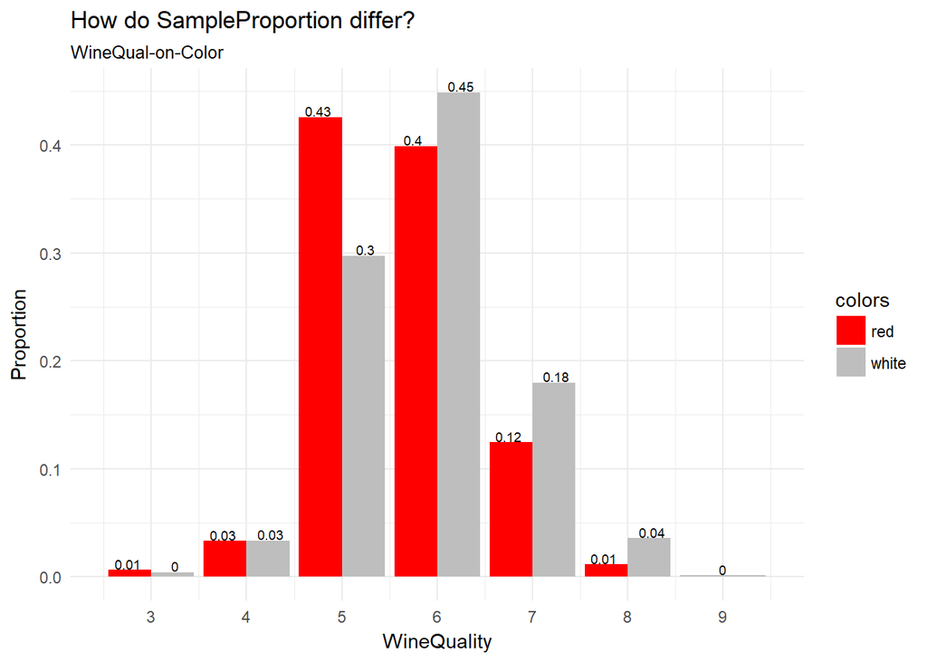

### Description One In the quality rating, white wines in general tend to start from a higher vantage ground than red wines.

### Plot Two

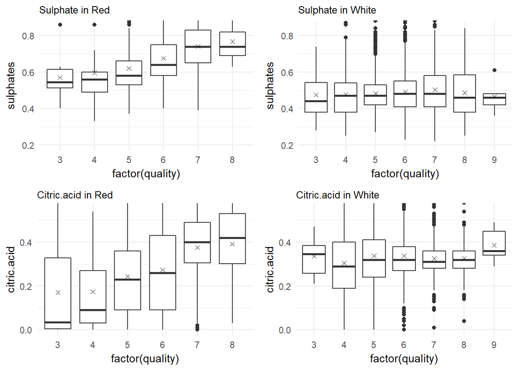

### Description Two ‘sulphates’ and ‘citric.acid’ help wines get rated higher in the red wine.

### Plot Three

### Based on P-value from the multinomial regression, and the correlation matrix, alcohol is another powerful predictor.

[figure not shown]

### Description Three

In the quality ratings range from 5 to 9, alcohol in general helps wines get rated higher.

### Final Plot Summary:

We are seeking for the features that help our wine get rated higher. Based on the duscussion above, we can say that white wine is generally easy to get higher rating, but if we maintain enough level of ‘sulphates’ and ‘citric.acid’, red wine can be compatible. In addition, alcohol is the powerful element that renders higher rating.

# Reflection

The wine quality data set was not hard to understand because from the discription offered, I could get some intuition of what this bunch of variables are talking about. I proceeded my analysis in a way to reaffirm my understanding of the discription and found lots of interesting relationships between these variables. What I struggled about was the missing rating of quality-‘9’ in the Red wine samples which gave me a sort of confusion, but it did not affect the result of analysis. Too many outliers in each variable were also bugging me but I decided to focus on the samples in the quantile from lower(25%) to upper(75%). The difference of the red and white in their sample size caused some confusions too, which was the reason I tried to use the proportion of the samples rather than their size.

Here, I made a set of interesting arguments: In general, red wines are rated lower than white wines, but if one added more additive(sulphates to increase S02 gas) and citric.acid, red wines would also be able to get rated higher. pH-level(3.11 ~ 3.21) is the range where ‘citric.acid’ and’ fixed.acidity’ work best. From the quality rating of 5, the advantage of alcohol in wines kicks off. However, there are still several question we need to answer. One can suspect that there might be a threshold or ceiling where alcohol does not work. The same is ture when it comes to ‘citric.acid’ and ‘sulphates’. Since there is a lack of wine samples with much highr alcolholic content or more ‘citric.acid’ and ‘sulphates’, we cannot say these properties are always the best to get rated higher.